# Replication Package for ‘Does homeownership hinder labor market activity? Evidence from housing privatization and restitution’

Stepan Mikula and Josef Montag

June 18, 2019

Contacts:

- stepan.mikula@econ.muni.cz | https://sites.google.com/site/stepanmikula.
- josef.montag@gmail.com | https://sites.google.com/site/josefmontag.

This package file contains R script and outputs reported in Mikula, Štěpán, and Josef Montag. 2019. Does homeownership hinder labor market activity? Evidence from housing privatization and restitution. MUNI ECON Working Paper No. 2019-06. Brno, Czech Republic: Department of Economics, Masaryk University.

The manuscript is available at https://ideas.repec.org/p/mub/wpaper/2019-06.html.

#### Data availability

*Privatized_houses.xls* is the database of privatized houses in Brno. For each house it contains address and the year of privatization. The dataset analyzed in the paper is built up on this database as described in the paper.

The individual-level census data used in this paper were provided by the Czech Statistical Office (CSO) under the condition of confidentiality and thus cannot be provided as part of this package. However, the data can be requested from the CSO and the authors can provide help with that.

```r
#Load libraries and functions, set constants and load data.

library(tidyverse)
library(rgdal)
library(broom)
library(ggmap)
library(stargazer)
library(lfe)
library(lmtest)
library(sandwich)
library(AER)
library(ivpack)
library(Formula)
library(geosphere)
library(DescTools)
library(readxl)
library(sf)
library(ggsn)
library(ggspatial)
library(ggmap)
library(cowplot)
library(sf)
library(knitr)

rm(list = ls())

# Load functions
source("CODE/functions.R")

# Constants

## Filtering
age_upper <- 61 #56
age_lower <- 19 #25
house_size <- 6 #6 minimum house size

## Matching
d_caliper <- 0.7
d_distance <- 700

## Robust clustered SE
cluster_by <- "house"

## Output format
table_type <- "text"

# Load data
load("DATA_RP/RPdata.RData")

# Number of digits
dig <- 3
```

Variables in `RPdata.RData`:

- `brno`…Map of Brno (sf polygon)
- `rzsj`…Map of neighborhoods (sf polygon)
- `rzsj_body`…Centroides of neighborhoods (sf point)
- `rzsj_houses`…No. of houses per group (type) and neighborhood (df)
- `r91_data_raw`…Census data from 1991 (no filtering applied)
- `r91_data`…1991 Census data (houses matching with 2001 census)
- `desc_91`…1991 Census data pre-processed for descriptives rendering
- `r91_houses`…1991 Census data aggregated by house
- `r01_data_raw`…2001 Census data (no filtering applied)
- `r01_data_basic`…2001 Census data (estimation sample)
- `r01_data`…2001 Census data (houses matching with 1991 census)

Other variables stored in separate files:

- `IDOB`…table for IDs conversion
- `privyear`…exact year of privatization
- `zsjsf`…equivalent of `rzsj` from `RPdata.RData`
- `rzsj` from `rzsj_centroides.RData`…centroides of neighborhoods (different format, simple df)

Key variables:

- `ownership`…owner/renter
- `RZSJ`…neighborhood code
- `EDUC`…education level
- `LPOHLAV`/`MALE`…gender
- `htype`…household type
- `BornBrno`/`BB`…individual born in Brno
- `LVEK`…age
- `LEKAKTI`…economic activity (1 = employed, 5 = unemployed)
- `JPOCBYT`/`byty`…house size
- `sample`…group of houses (ATT = privatized before 2001, NTR = restituted, NTP = privatized in 2001 or later, NTC = city-owned and never privatized)

## Formulas

```r
# Individual data models
model <- list(
  I(LEKAKTI == 5) ~ ownership,
  I(LEKAKTI == 5) ~ ownership + factor(RZSJ),
  I(LEKAKTI == 5) ~ ownership + EDUC,
  I(LEKAKTI == 5) ~ ownership + EDUC + LPOHLAV  + htype + BornBrno + factor(LVEK),
  I(LEKAKTI == 5) ~ ownership + EDUC + LPOHLAV  + htype + BornBrno + factor(RZSJ) + factor(LVEK)
) %>% lapply(as.Formula)

# Change dependent variable from unemployment to economic activity
model <- c(
  model,
  #model %>% lapply(update, I(LEKAKTI == 1) ~ .),
  model %>% lapply(update, I(LEKAKTI %in% c(1,5)) ~ .)
)

model_individual <- model

# Individual data models, gender-specific subsamples (not used)

model_individual_gender <- model_individual %>% lapply(update, .~. - LPOHLAV)

# Individual data models (IV)

modeliv_individual <- list(
  I(LEKAKTI == 5) ~ ownership | sample_dummy,
  I(LEKAKTI == 5) ~ ownership + factor(RZSJ) | sample_dummy + factor(RZSJ),
  I(LEKAKTI == 5) ~ ownership + EDUC | sample_dummy + EDUC,
    I(LEKAKTI == 5) ~ ownership + EDUC + LPOHLAV  + htype + BornBrno + factor(LVEK) | sample_dummy + EDUC + LPOHLAV  + htype + BornBrno + factor(LVEK),
  I(LEKAKTI == 5)  ~ ownership + EDUC + LPOHLAV  + htype + BornBrno + factor(RZSJ) + factor(LVEK) | sample_dummy + EDUC + LPOHLAV + htype + BornBrno + factor(RZSJ) + factor(LVEK)
) %>% lapply(as.Formula)

modeliv_1ststage <- list(
  ownership ~ sample_dummy,
  ownership ~ sample_dummy + factor(RZSJ),
  ownership ~ sample_dummy + EDUC,
  ownership ~ sample_dummy + EDUC + LPOHLAV + factor(LVEK) + htype + BornBrno,
  ownership ~ sample_dummy + EDUC + LPOHLAV + factor(LVEK) + htype + BornBrno + factor(RZSJ)
) %>% lapply(as.Formula)

# Change dependent variable from unemployment to economic activity

modeliv_individual <- c(
  modeliv_individual,
  modeliv_individual %>% lapply(update, I(LEKAKTI %in% c(1,5)) ~ .)
)

# Individual data models, gender-specific subsamples

modeliv_individual_gender <- modeliv_individual %>% lapply(update, .~. - LPOHLAV | . - LPOHLAV)

# Decision to privatize

model_fs <- list(
  I(sample != "NTC") ~ LVEK + MALE + EDUCmiddle + EDUChigh + BornBrno + byty,
  I(sample != "NTC") ~ LVEK + MALE + EDUCmiddle + EDUChigh + BornBrno + byty + factor(RZSJ)
) %>% lapply(as.Formula)

model_fs <- c(
  model_fs,
  model_fs %>% lapply(update, I(sample == "ATT") ~ .)
)

model_propscore <- as.Formula(X ~ EDUChigh + EDUCmiddle + BornBrno + LVEK + MALE + JPOCBYT + U + EA)
```

## Summary statistics

### Maps

#### Figure 3a

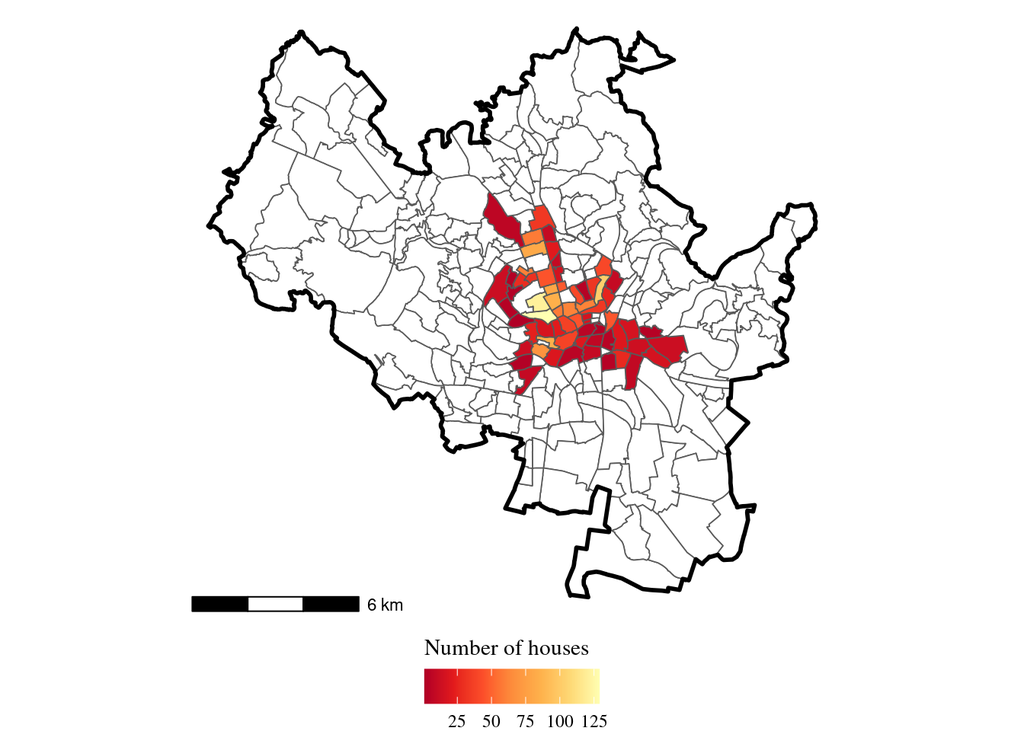

```r
# Calculate no. of houses per neighborhood (ZSJ)
rzsj_houses <- r01_data_basic %>%
  select(adresado_01_klic,sample,RZSJ) %>%
  distinct() %>%
  #group_by(sample,RZSJ) %>%
  group_by(RZSJ) %>%
  summarise(
    obs = n()
  ) %>%
  ungroup() %>%
  #spread(sample,obs) %>%
  mutate(
    KOD_ZSJ = str_sub(RZSJ,1,6)
  )

rzsj %>%
  rename(geometry = SHAPE) %>%
  left_join(rzsj_houses) %>%
  ggplot() +
  geom_sf(
    aes(fill = obs),
    size = 0.3
  ) +
  geom_sf(
    data = brno,
    fill = NA,
    size = 1,
    color = "black"
  ) +
  annotation_scale() +
  coord_sf(
    datum = NA
  ) +
  scale_fill_distiller(
    name = "Number of houses",
    palette = "YlOrRd",
    na.value = "white",
    guide = guide_colorbar(
      direction = "horizontal",
      title.position = "top"
        )
  ) +
  theme_void(
    base_family = "times"
  ) +
  theme(
    legend.position = "bottom"
  )
```

#### Figure 3b

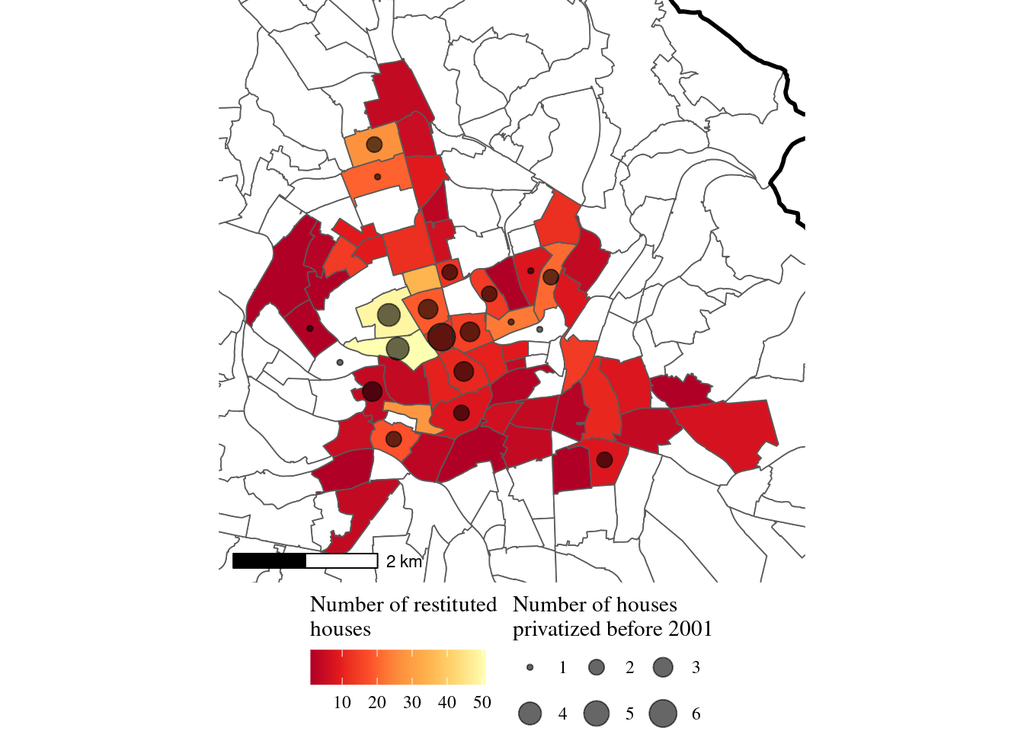

```r
bbox <- rzsj %>%
  rename(geometry = SHAPE) %>%
  left_join(rzsj_houses) %>%
  filter(!is.na(obs)) %>%
  st_bbox()

rzsj_houses <- r01_data_basic %>%
  filter(sample %in% c("ATT","NTR")) %>%
  select(adresado_01_klic,sample,RZSJ) %>%
  distinct() %>%
  group_by(sample,RZSJ) %>%
  #group_by(RZSJ) %>%
  summarise(
    obs = n()
  ) %>%
  ungroup() %>%
  spread(sample,obs) %>%
  mutate(
    KOD_ZSJ = str_sub(RZSJ,1,6)
  )

ATTbody <- left_join(rzsj_body,rzsj_houses) %>%
  rename(geomtry = SHAPE) %>%
  filter(!is.na(ATT))

NTRshape <- rzsj %>%
  rename(geometry = SHAPE) %>%
  left_join(rzsj_houses)

NTRshape %>%
  ggplot() +
  geom_sf(
    aes(fill = NTR),
    size = 0.3
  ) +
  geom_sf(
    data = ATTbody,
    aes(size = ATT),
    show.legend = "point",
    alpha = 0.6
  ) +
  geom_sf(
    data = brno,
    fill = NA,
    size = 1,
    color = "black"
  ) +
  annotation_scale() +
  coord_sf(
    datum = NA,
    xlim = bbox[c(1,3)],
    ylim = bbox[c(2,4)]
  ) +
  scale_fill_distiller(
    name = "Number of restituted\nhouses",
    palette = "YlOrRd",
    na.value = "white",
    guide = guide_colorbar(
      direction = "horizontal",
      title.position = "top"
        )
  ) +
  scale_size(
    name = "Number of houses\nprivatized before 2001",
    guide = guide_legend(
      direction = "horizontal",
      title.position = "top",
      byrow = TRUE
        )
  ) +
  theme_void(
    base_family = "times"
  ) +
  theme(
    legend.direction = "vertical"
  ) +
  theme(
    legend.position = "bottom"
  )
```

#### Table 1: Apartment buildings in Brno in 1991, means by privatization and restitution status

```r
desc_91 %>%
  mutate(
    EDUClow = as.integer(EDUC == "low"),
    EDUCmiddle = as.integer(EDUC == "middle"),
    EDUChigh = as.integer(EDUC == "high")
  ) %>%
  select(-EDUC) %>%
  group_by(adresado_01_klic,sample) %>%
  summarise_if(is.numeric, mean, na.rm = TRUE) %>%
  ungroup()  -> desc_91_houses_klic

desc_91_houses_klic %>%
  select(-adresado_01_klic) -> desc_91_houses

desc_91_houses <- r91_houses %>%
  select(-adresado_01_klic)

## City-owned
CityOwned <- desc_91_houses %>%
  select(-Act) %>%
  filter(sample != "NTR") %>%
  desctable() %>%
  format_desctable() %>%
  rename(CityOwned = value)

## Restituted
Restituted <- desc_91_houses %>%
  select(-Act) %>%
  filter(sample == "NTR") %>%
  desctable() %>%
  format_desctable() %>%
  rename(Restituted = value)

# Diff (1) and (2)
desc_91_houses %>%
  select(-Act) %>%
  mutate(
    sample = case_when(
      sample != "NTR" ~ "CO",
      TRUE ~ "NTR"
    )
  ) %>%
  gather(variable,value,-sample) %>%
  mutate(
    sample = factor(sample) %>% relevel(ref = "CO")
  ) %>%
  #drop_na(value) %>%
  mutate(value = as.double(value)) %>%
  group_by(variable) %>%
  do(
    estmlm = lm(
      value ~ sample,
      data = .
    ) %>%
      coeftest(vcov. = vcovHC) %>% tidy() %>%
      filter(str_detect(term,"sample"))
  ) %>%
  ungroup() %>%
  unnest(estmlm) %>%
  rowwise() %>%
  mutate(
    mean = estimate %>% format(digits = 1, nsmall = dig, trim = TRUE, scientific = FALSE) %>%
      str_c(.,add_stars(p.value, latex = TRUE)),
    se = std.error %>% format(digits = 1, nsmall = dig, trim = TRUE, scientific = FALSE) %>%
      str_c("(",.,")")
  ) %>%
  ungroup() %>%
  select(variable,mean,se) %>%
  gather(stat,dif1,-variable) -> dif1


## Subgroups
SelectedForP <- desc_91_houses %>%
  filter(sample != "NTR") %>%
  filter(!is.na(Act)) %>%
  select(-Act) %>%
  desctable() %>%
  format_desctable() %>%
  rename(SelectedForP = value)

SelectedForP_priv <- desc_91_houses %>%
  filter(sample != "NTR") %>%
  filter(!is.na(Act)) %>%
  filter(sample == "ATT") %>%
  select(-Act) %>%
  desctable() %>%
  format_desctable() %>%
  rename(SelectedForP_priv = value)


SelectedForP_notpriv <- desc_91_houses %>%
  filter(sample != "NTR") %>%
  filter(!is.na(Act)) %>%
  filter(sample != "ATT") %>%
  select(-Act) %>%
  desctable() %>%
  format_desctable() %>%
  rename(SelectedForP_notpriv = value)

NotSelected <- desc_91_houses %>%
  filter(sample != "NTR") %>%
  filter(is.na(Act)) %>%
  select(-Act) %>%
  desctable() %>%
  format_desctable() %>%
  rename(NotSelected = value)


desc_91_houses %>%
  filter(sample != "NTR") %>%
  mutate(
    sample = case_when(
      is.na(Act) ~ "NDp",
      TRUE ~ "Dp"
    )
  ) %>%
  select(-Act) %>%
  gather(variable,value,-sample) %>%
  mutate(
    sample = factor(sample) %>% relevel(ref = "Dp")
  ) %>%
  #drop_na() %>%
  mutate(value = as.double(value)) %>%
  group_by(variable) %>%
  do(
    estmlm = lm(
      value ~ sample,
      data = .
    ) %>%
      coeftest(vcov. = vcovHC) %>% tidy() %>%
      filter(str_detect(term,"sample"))
  ) %>%
  ungroup() %>%
  unnest(estmlm) %>%
  rowwise() %>%
  mutate(
    mean = estimate %>% format(digits = 1, nsmall = dig, trim = TRUE, scientific = FALSE) %>%
      str_c(.,add_stars(p.value, latex = TRUE)),
    se = std.error %>% format(digits = 1, nsmall = dig, trim = TRUE, scientific = FALSE) %>%
      str_c("(",.,")")
  ) %>%
  ungroup() %>%
  select(variable,mean,se) %>%
  gather(stat,dif2,-variable) -> dif2


FullSample <- desc_91_houses %>%
  #filter(sample != "NTR") %>%
  #filter(is.na(Act)) %>%
  select(-Act) %>%
  desctable() %>%
  format_desctable() %>%
  rename(FullSample = value)

house_tab91 <- list(
  #FullSample,
  Restituted,
  CityOwned,
  NotSelected,
  SelectedForP,
  SelectedForP_priv,
  SelectedForP_notpriv,
  dif1,
  dif2
) %>%
  reduce(full_join) %>%
  mutate(
    variable = ifelse(stat == "n","obs",variable)
  ) %>%
  filter(
    !(variable %in% c("EXP","E"))
  ) %>%
  gather(sample,value,-variable,-stat) %>%
  mutate(
    value = ifelse(stat == "n",as.character(as.integer(value)),value)
  ) %>%
  spread(sample,value) %>%
  mutate(
    variable = factor(
      variable,
      levels = c("EA","E","U","MALE","LVEK","EDUClow","EDUCmiddle","EDUChigh",
                                             "EXP","BB",
                                             "htypeComplete_family","htypeIncomplete_family",
                                             "htypeNon_family_household","htypeOne_person_household","POC_BYTU","obs"),
                       labels = c("Economically active (share)",
                                  "Employed (share)",
                                  "Unemployed (share)",
                                  "Male (share)", "Age",
                                  "Primary education (share)",
                                  "Secondary education (share)",
                                  "Tertiary education (share)",
                                  "Potential experience","Born in Brno (share)",
                                  "Household type: Complete family",
                                  "Household type: Incomplete family",
                                  "Household type: Non-family household",
                                  "Household type: One-person household",
                                  "Number of apartments",
                                  "Houses")
    )
  ) %>%
  arrange(variable,stat) %>%
  mutate_all(as.character) %>%
  mutate(
    variable = ifelse(stat == "se","",variable)
  ) %>%
  select(
    variable,
  #FullSample,
  Restituted,
  CityOwned,
  NotSelected,
  SelectedForP,
  SelectedForP_priv,
  SelectedForP_notpriv,
  dif1,
  dif2
  )

house_tab91 %>%
  mutate_all(replace_na,"") %>%
  mutate_all(str_remove_all,"\\\\c") %>%
      mutate_all(str_remove_all,"\\{") %>%
      mutate_all(str_remove_all,"\\}") %>%
      mutate_all(str_remove_all,"\\^") %>%
  kable(
    col.names = c(
      "Variable",
      str_c("(",1:8,")")
    )
  )
```

| Variable | (1) | (2) | (3) | (4) | (5) | (6) | (7) | (8) |
| --- | --- | --- | --- | --- | --- | --- | --- | --- |
| Economically active (share) | 0.526 | 0.506 | 0.499 | 0.562 | 0.580 | 0.553 | 0.021*** | -0.063*** |
|  | (0.006) | (0.004) | (0.005) | (0.011) | (0.020) | (0.014) | (0.008) | (0.012) |
| Unemployed (share) | 0.027 | 0.023 | 0.023 | 0.024 | 0.022 | 0.025 | 0.004* | -0.001 |
|  | (0.002) | (0.001) | (0.001) | (0.003) | (0.005) | (0.004) | (0.002) | (0.003) |
| Male (share) | 0.443 | 0.442 | 0.441 | 0.451 | 0.461 | 0.446 | 0.0008 | -0.010 |
|  | (0.003) | (0.002) | (0.002) | (0.006) | (0.011) | (0.007) | (0.004) | (0.006) |
| Age | 49.590 | 50.036 | 50.290 | 47.874 | 47.288 | 48.149 | -0.446 | 2.416*** |
|  | (0.257) | (0.172) | (0.184) | (0.432) | (0.760) | (0.527) | (0.309) | (0.469) |
| Primary education (share) | 0.556 | 0.573 | 0.586 | 0.466 | 0.444 | 0.476 | -0.017* | 0.120*** |
|  | (0.007) | (0.005) | (0.005) | (0.015) | (0.026) | (0.018) | (0.009) | (0.016) |
| Secondary education (share) | 0.286 | 0.282 | 0.278 | 0.319 | 0.317 | 0.321 | 0.003 | -0.041*** |
|  | (0.005) | (0.003) | (0.004) | (0.010) | (0.015) | (0.012) | (0.006) | (0.010) |
| Tertiary education (share) | 0.159 | 0.145 | 0.136 | 0.215 | 0.239 | 0.203 | 0.014** | -0.078*** |
|  | (0.005) | (0.003) | (0.003) | (0.011) | (0.021) | (0.012) | (0.006) | (0.011) |
| Houses | 605 | 1371 | 1227 | 144 | 46 | 98 |  |  |
|  | 0.534 | 0.499 | 0.495 | 0.528 | 0.558 | 0.513 | 0.036*** | -0.033*** |
|  | 11.398 | 12.002 | 11.944 | 12.500 | 11.435 | 13.000 | -0.604** | -0.556 |
|  | 13.140 | 13.917 | 13.560 | 16.958 | 16.304 | 17.265 | -0.776** | -3.398*** |
|  | (0.006) | (0.004) | (0.004) | (0.011) | (0.014) | (0.014) | (0.007) | (0.012) |
|  | (0.199) | (0.134) | (0.143) | (0.397) | (0.561) | (0.517) | (0.240) | (0.422) |
|  | (0.279) | (0.186) | (0.194) | (0.563) | (0.951) | (0.701) | (0.335) | (0.596) |

```r
r01_data_basic %>%
  select(one_of(all.vars(model[[5]])),adresado_01_klic,flat_ID,sample,priv_year,Act,LVEK) %>%
  drop_na(-priv_year,-Act) %>%
  mutate(
    U = as.integer(LEKAKTI == 5),
    #E = as.integer(LEKAKTI == 1),
    EA = as.integer(LEKAKTI %in% c(1,5)),
    owner = as.integer(ownership == "owner"),
    EDUClow = as.integer(EDUC == "low"),
    EDUCmiddle = as.integer(EDUC == "middle"),
    EDUChigh = as.integer(EDUC == "high"),
    MALE = as.integer(LPOHLAV == "male"),
    htypeIncomplete_family = as.integer(htype == "Incomplete_family"),
    htypeComplete_family = as.integer(htype == "Complete_family"),
    htypeOne_person_household = as.integer(htype == "One_person_household")
  ) %>%
  #select(-EXP) %>%
  select(-LEKAKTI,-ownership,-EDUC,-LPOHLAV,-RZSJ,-htype) -> desc01_ind


## Restituted

Ntab <- desc01_ind %>%
  filter(sample == "NTR") %>%
  summarise(
    individuals = n(),
    houses = unique(adresado_01_klic) %>% length(),
    households = unique(flat_ID) %>% length()
  ) %>% mutate_all(as.character) %>%
  gather(variable,value) %>%
  mutate(stat = "n")

NTRstat <- desc01_ind %>%
  filter(sample == "NTR") %>%
  select(-Act,-adresado_01_klic,-flat_ID) %>%
  desctable() %>%
  format_desctable() %>%
  bind_rows(.,Ntab) %>%
  rename(NTR = value)

## City-owned

Ntab <- desc01_ind %>%
  filter(sample != "NTR") %>%
  summarise(
    individuals = n(),
    houses = unique(adresado_01_klic) %>% length(),
    households = unique(flat_ID) %>% length()
  ) %>% mutate_all(as.character) %>%
  gather(variable,value) %>%
  mutate(stat = "n")

COstat <- desc01_ind %>%
  filter(sample != "NTR") %>%
  select(-Act,-adresado_01_klic,-flat_ID) %>%
  desctable() %>%
  format_desctable() %>%
  bind_rows(.,Ntab) %>%
  rename(CO = value)

## Privatized
Ntab <- desc01_ind %>%
  filter(sample == "ATT") %>%
  summarise(
    individuals = n(),
    houses = unique(adresado_01_klic) %>% length(),
    households = unique(flat_ID) %>% length()
  ) %>% mutate_all(as.character) %>%
  gather(variable,value) %>%
  mutate(stat = "n")

ATTstat <- desc01_ind %>%
  filter(sample == "ATT") %>%
  select(-Act,-adresado_01_klic,-flat_ID) %>%
  desctable() %>%
  format_desctable() %>%
  bind_rows(.,Ntab) %>%
  rename(ATT = value)

## City-owned/NTP

Ntab <- desc01_ind %>%
  filter(sample == "NTP") %>%
  summarise(
    individuals = n(),
    houses = unique(adresado_01_klic) %>% length(),
    households = unique(flat_ID) %>% length()
  ) %>% mutate_all(as.character) %>%
  gather(variable,value) %>%
  mutate(stat = "n")

NTPstat <- desc01_ind %>%
  filter(sample == "NTP") %>%
  select(-Act,-adresado_01_klic,-flat_ID) %>%
  desctable() %>%
  format_desctable() %>%
  bind_rows(.,Ntab) %>%
  rename(NTP = value)

## City-owned/NTC

Ntab <- desc01_ind %>%
  filter(sample == "NTC") %>%
  summarise(
    individuals = n(),
    houses = unique(adresado_01_klic) %>% length(),
    households = unique(flat_ID) %>% length()
  ) %>% mutate_all(as.character) %>%
  gather(variable,value) %>%
  mutate(stat = "n")

NTCstat <- desc01_ind %>%
  filter(sample == "NTC") %>%
  select(-Act,-adresado_01_klic,-flat_ID) %>%
  desctable() %>%
  format_desctable() %>%
  bind_rows(.,Ntab) %>%
  rename(NTC = value)


### dif1

desc01_ind %>%
  filter(sample %in% c("NTR","ATT")) %>%
  select(-Act,-adresado_01_klic,-flat_ID) %>%
  select(-priv_year) %>%
  gather(variable,value,-sample) %>%
  mutate(
    sample = factor(sample) %>% relevel(ref = "ATT")
  ) %>%
  group_by(variable) %>%
  do(
    estmlm = lm(
      value ~ sample,
      data = .
    ) %>%
      coeftest(vcov. = vcovHC) %>% tidy() %>%
      filter(str_detect(term,"sample"))
  ) %>%
  ungroup() %>%
  unnest(estmlm) %>%
  rowwise() %>%
  mutate(
    mean = estimate %>% format(digits = 1, nsmall = 3, trim = TRUE, scientific = FALSE) %>%
      str_c(.,add_stars(p.value, latex = TRUE)),
    se = std.error %>% format(digits = 1, nsmall = 3, trim = TRUE, scientific = FALSE) %>%
      str_c("(",.,")")
  ) %>%
  ungroup() %>%
  select(variable,mean,se) %>%
  gather(stat,dif1,-variable) -> dif1



estsamp2001 <- list(
  NTRstat,
  ATTstat,
  NTPstat,
  NTCstat,
  COstat,
  dif1
) %>%
  reduce(full_join) %>%
  # mutate(
  #   variable = ifelse(stat == "n","obs",variable)
  # ) %>%
  filter(
    !(variable %in% c("EXP","E","Observations"))
  ) %>%
  gather(
  sample,value,-variable,-stat
  ) %>%
  mutate(
    value = ifelse(stat == "n", format(as.integer(value), big.mark = ",", trim = TRUE), value)
  ) %>%
  spread(sample,value) %>%
  mutate(
    variable = factor(
      variable,
      levels = c("EA","E","U","MALE","LVEK","EDUClow","EDUCmiddle","EDUChigh",
                                             "EXP","BornBrno",
                                             "htypeComplete_family","htypeIncomplete_family",
                                             "htypeNon_family_household","htypeOne_person_household","owner",
                 "individuals","households","houses"),
                       labels = c("Economically active (=1)",
                                  "Employed (=1)",
                                  "Unemployed (=1)",
                                  "Male (=1)", "Age",
                                  "Primary education (=1)",
                                  "Secondary education (=1)",
                                  "Tertiary education (=1)",
                                  "Potential experience","Born in Brno (=1)",
                                  "Household type: Complete family (=1)",
                                  "Household type: Incomplete family (=1)",
                                  "Household type: Non-family household (=1)",
                                  "Household type: One-person household (=1)",
                                  "Owner (=1)",
                                  "Individuals",
                                  "Households",
                                  "Houses")
    )
  ) %>%
  arrange(variable,stat) %>%
  mutate_all(as.character) %>%
  mutate(
    variable = ifelse(stat == "se","",variable)
  ) %>%
  select(
    variable,
    NTR,
  ATT,
  NTP,
  NTC,
  CO,
  dif1
  )

estsamp2001  %>%
  mutate_all(as.character) %>%
  mutate_all(replace_na,"") %>%
  mutate_all(str_remove_all,"\\\\c") %>%
      mutate_all(str_remove_all,"\\{") %>%
      mutate_all(str_remove_all,"\\}") %>%
      mutate_all(str_remove_all,"\\^") %>%
  kable(
    col.names = c(
      "Variable",
      str_c("(",1:6,")")
    )
  )
```

| Variable | (1) | (2) | (3) | (4) | (5) | (6) |
| --- | --- | --- | --- | --- | --- | --- |
| Economically active (=1) | 0.786 | 0.787 | 0.795 | 0.786 | 0.792 | -0.001 |
|  | (0.005) | (0.017) | (0.004) | (0.005) | (0.003) | (0.018) |
| Unemployed (=1) | 0.099 | 0.060 | 0.097 | 0.116 | 0.103 | 0.039*** |
|  | (0.004) | (0.010) | (0.003) | (0.004) | (0.002) | (0.010) |
| Male (=1) | 0.487 | 0.494 | 0.475 | 0.484 | 0.479 | -0.007 |
|  | (0.006) | (0.020) | (0.005) | (0.006) | (0.004) | (0.021) |
| Age | 39.453 | 39.476 | 39.109 | 39.032 | 39.092 | -0.023 |
|  | (0.155) | (0.492) | (0.122) | (0.146) | (0.092) | (0.516) |
| Primary education (=1) | 0.409 | 0.307 | 0.399 | 0.473 | 0.425 | 0.102*** |
|  | (0.006) | (0.019) | (0.005) | (0.006) | (0.004) | (0.020) |
| Secondary education (=1) | 0.367 | 0.365 | 0.378 | 0.341 | 0.363 | 0.002 |
|  | (0.006) | (0.020) | (0.005) | (0.006) | (0.004) | (0.021) |
| Tertiary education (=1) | 0.225 | 0.328 | 0.223 | 0.187 | 0.212 | -0.104*** |
|  | (0.005) | (0.019) | (0.004) | (0.005) | (0.003) | (0.020) |
| Born in Brno (=1) | 0.646 | 0.668 | 0.633 | 0.634 | 0.635 | -0.023 |
|  | (0.006) | (0.019) | (0.005) | (0.006) | (0.004) | (0.020) |
| Household type: Complete family (=1) | 0.628 | 0.690 | 0.622 | 0.618 | 0.623 | -0.062*** |
|  | (0.006) | (0.019) | (0.005) | (0.006) | (0.004) | (0.020) |
| Household type: Incomplete family (=1) | 0.205 | 0.206 | 0.222 | 0.215 | 0.219 | -0.001 |
|  | (0.005) | (0.017) | (0.004) | (0.005) | (0.003) | (0.017) |
| Household type: One-person household (=1) | 0.167 | 0.104 | 0.155 | 0.167 | 0.158 | 0.063*** |
|  | (0.005) | (0.013) | (0.004) | (0.005) | (0.003) | (0.013) |
| Owner (=1) | 0.000 | 0.913 | 0.000 | 0.000 | 0.033 | -0.913*** |
|  | (0.000) | (0.012) | (0.000) | (0.000) | (0.001) | (0.012) |
| Individuals | 6,088 | 597 | 9,552 | 6,611 | 16,760 | NA |
| Households | 3,556 | 329 | 5,725 | 4,007 | 10,061 | NA |
| Houses | 599 | 46 | 774 | 548 | 1,368 | NA |

## OLS

### Table 3: Homeownership and labor market activity (OLS), individuals from houses privatized before 2001 and all restituted houses

```r
model <- model_individual

# Remove incomplete observations
model %>%
  lapply(all.vars) %>%
  unlist() %>%
  unique() %>%
  c("flat_ID","sample","RZSJ","MALE","adresado_01_klic",.) -> all_vars

r01_data_x <- r01_data_basic %>%
  dplyr::select(one_of(all_vars)) %>%
  drop_na()
```

```r
r01_data_x %>%
  filter(sample %in% c("ATT","NTR")) -> reg_data

reg_data_ea <- reg_data %>% filter(LEKAKTI %in% c(1,5))

#save(reg_data, reg_data_ea, file = "DATA/processed/fullNAIVE_data.RData")

c(
  model[1:5] %>% lapply(function(x) lm(x, data = reg_data_ea)),
  model[6:10] %>% lapply(function(x) lm(x, data = reg_data))
  ) -> estm

if(cluster_by == "flat"){
  c(
    estm[1:5] %>% lapply(function(x) coeftest(x, vcov. = vcovCL(x, reg_data_ea$flat_ID))),
    estm[6:10] %>% lapply(function(x) coeftest(x, vcov. = vcovCL(x, reg_data$flat_ID)))
  ) -> estm_ctest
}else{
  c(
    estm[1:5] %>% lapply(function(x) coeftest(x, vcov. = vcovCL(x, reg_data_ea$adresado_01_klic))),
    estm[6:10] %>% lapply(function(x) coeftest(x, vcov. = vcovCL(x, reg_data$adresado_01_klic)))
  ) -> estm_ctest
}

get_tables(estm, estm_ctest, reorder = c(6,7,8,9,10,1,2,3,4,5), space = FALSE) %>%
  mutate_all(replace_na,"") %>%
  kable(
    col.names = c(
      "Variable",
      str_c("(",1:10,")")
    )
  )
```

| Variable | (1) | (2) | (3) | (4) | (5) | (6) | (7) | (8) | (9) | (10) |
| --- | --- | --- | --- | --- | --- | --- | --- | --- | --- | --- |
| Homeowner (=1) | 0.009 | 0.002 | -0.007 | -0.002 | -0.005 | -0.060*** | -0.052*** | -0.038*** | -0.036*** | -0.038*** |
|  | (0.015) | (0.016) | (0.015) | (0.014) | (0.016) | (0.014) | (0.014) | (0.014) | (0.013) | (0.013) |
| Secondary education (=1) |  |  | -0.005 | 0.026** | 0.027** |  |  | -0.123*** | -0.123*** | -0.119*** |
|  |  |  | (0.012) | (0.011) | (0.011) |  |  | (0.012) | (0.012) | (0.012) |
| Tertiary education (=1) |  |  | 0.133*** | 0.095*** | 0.097*** |  |  | -0.178*** | -0.157*** | -0.153*** |
|  |  |  | (0.012) | (0.011) | (0.011) |  |  | (0.011) | (0.011) | (0.011) |
| Male (=1) |  |  |  | 0.157*** | 0.157*** |  |  |  | 0.001 | 0.0001 |
|  |  |  |  | (0.009) | (0.009) |  |  |  | (0.008) | (0.008) |
| Born in Brno (=1) |  |  |  | -0.004 | -0.005 |  |  |  | 0.004 | 0.007 |
|  |  |  |  | (0.009) | (0.009) |  |  |  | (0.010) | (0.010) |
| Incomplete family (=1) |  |  |  | 0.028** | 0.028** |  |  |  | 0.066*** | 0.063*** |
|  |  |  |  | (0.012) | (0.012) |  |  |  | (0.013) | (0.013) |
| One-person family (=1) |  |  |  | 0.015 | 0.014 |  |  |  | 0.051*** | 0.051*** |
|  |  |  |  | (0.012) | (0.013) |  |  |  | (0.013) | (0.013) |
| Constant | 0.786*** |  | 0.758*** |  |  | 0.127*** |  | 0.215*** |  |  |
|  | (0.005) |  | (0.009) |  |  | (0.006) |  | (0.011) |  |  |
| Age dummies | – | – | – | Yes | Yes | – | – | – | Yes | Yes |
| Neighborhood dummies | – | Yes | – | – | Yes | – | Yes | – | – | Yes |
| Observations | 6,685 | 6,685 | 6,685 | 6,685 | 6,685 | 5,256 | 5,256 | 5,256 | 5,256 | 5,256 |
| $R2$ | 0.00004 | 0.009 | 0.020 | 0.219 | 0.224 | 0.003 | 0.021 | 0.054 | 0.092 | 0.102 |

## Matching

```r
#Add RZSJ coordinates.
houses <- r01_data %>%
  group_by(adresado_01_klic) %>%
  dplyr::summarise(
    RCASTOBCE = first(RCASTOBCE),
    RZSJ = first(RZSJ)#,
    #JPOCBYT = first(JPOCBYT)
  ) %>%
  mutate(
    RZSJ = str_sub(RZSJ, start = 1, end = 6)
  ) %>%
  ungroup() %>%
  distinct()

load("DATA_RP/rzsj_centroides.RData")

rzsj %>%
  as.data.frame() %>%
  as_data_frame() %>%
  dplyr::select(
    RZSJ = KOD_ZSJ, long = coords.x1, lat = coords.x2
  ) %>%
  mutate(
    RZSJ = as.character(RZSJ)
  ) %>%
  distinct() %>%
  left_join(houses,., by = "RZSJ") %>%
  drop_na() -> houses

desc_91_houses_klic %>%
  left_join(houses) -> r91_houses
```

### Table A1: Balancing test (means), matched houses in 1991

```r
# Propensity score
r91_houses %>%
  dplyr::select(-Act) %>%
  filter(sample %in% c("ATT","NTR")) %>%
  filter(adresado_01_klic %in% r01_data_basic$adresado_01_klic) %>%
  #filter(JPOCBYT >= 6) %>%
  rename(JPOCBYT = POC_BYTU) %>%
  mutate(
    byty = cut(JPOCBYT, c(0,10,20,40), right = FALSE)
  ) %>%
  drop_na() %>%
  rename(BornBrno = BB) -> r91_houses_sample1


att_selection <- glm(update(model_propscore, I(sample == "ATT") ~ .),
                     data = r91_houses_sample1, family = binomial("logit"))

r91_houses_sample1 %>%
  predict.glm(att_selection, type = "response", newdata = .) -> r91_houses_sample1$pscore


### Regression data
modeliv <- modeliv_individual #%>% lapply(matchingFE)
model_rob <- modeliv[[5]]

# Remove incomplete observations
model_rob %>%
  lapply(all.vars) %>%
  unlist() %>%
  unique() %>%
  c("flat_ID","sample","RZSJ","MALE","adresado_01_klic","person_ID",.) -> all_vars

r01_data_x <- r01_data_basic %>%
  dplyr::select(one_of(all_vars)) %>%
  drop_na()

r01_data_x %>%
  filter(sample %in% c("ATT","NTR")) %>%
  mutate(
    ownership = ownership == "owner",
    sample_dummy = sample == "ATT"
    ) -> reg_data

reg_data_ea <- reg_data %>% filter(LEKAKTI %in% c(1,5))

## Unemployment

load("DATA_RP/zsjsf.RData")

crossing(
  C = seq(from=0.1, to = 0.9, by = 0.1),
  D = c(100,400,700,1000)
) %>%
  #filter(D %in% c(100,400,700,1000)) %>%
  # filter(D == 700) %>%
  # filter(C == 0.4) %>%
  rowwise() %>%
  mutate(
    match = get_matched.geo(r91_houses_sample1, C, D, geo = zsjsf) %>% list(),
    #match = matchO$DataX %>% list(),
    emod  = get_ownership.g0(match$match, xdata = reg_data_ea, xmodel = model_rob) %>% list(),
    owner = emod$coefs %>% filter(str_detect(term,"ownershipTRUE")) %>% list()
  ) -> outputs_U
```

[output not shown]

[output cut: 21 more lines]

```r
outputs_U %>%
  unnest(owner) %>%
  rowwise() %>%
  mutate(
    n_t = match$match %>% filter(ctg == "treatment") %>% distinct(adresado_01_klic) %>% nrow(),
    n_c = match$match %>% filter(ctg == "control") %>% distinct(adresado_01_klic) %>% nrow()
  ) -> outputs_U


# Balance test
outputs_U %>%
  #filter(C==d_caliper,D==d_distance) %>%
  filter(is_equal(C,d_caliper)) %>%
  filter(is_equal(D,d_distance)) %>%
  pull(match) -> baseline_match

aux <- baseline_match[[1]]$match %>%
  left_join(r91_houses_sample1, by = "adresado_01_klic") %>%
  select(-adresado_01_klic,-sample,-RZSJ,-RCASTOBCE,-long,-lat,-byty) %>%
  gather(variable,value,-ctg,-id,-W)

aux1 <- aux %>%
  group_by(ctg,variable) %>%
  do(
    mean = lm(value ~ 1, data = ., weights = W) %>% coeftest(vcov. = vcovHC) %>% tidy() %>% filter(str_detect(term,"Intercept"))
  ) %>%
  ungroup() %>%
  unnest(mean) %>%
  rowwise() %>%
  mutate(
    estimate = format(estimate, digits = 1, nsmall=3, trim = TRUE, scientific = FALSE),
    std.error = format(std.error, digits = 1, nsmall=3, trim = TRUE, scientific = FALSE) %>% str_c("(",.,")")
  ) %>%
  ungroup() %>%
  select(ctg,variable,estimate,std.error) %>%
  gather(stat,value,-ctg,-variable) %>%
  spread(ctg,value)

aux %>%
  mutate(
    ctg = factor(ctg) %>% relevel(ref = "control")
  ) %>%
  group_by(variable) %>%
  do(
    dif = lm(value ~ ctg, data = ., weights = W) %>% coeftest(vcov. = vcovHC) %>% tidy() %>% filter(str_detect(term,"ctg"))
  ) %>%
  ungroup() %>%
  unnest(dif) %>%
  rowwise() %>%
  mutate(
    estimate = format(estimate, digits = 1, nsmall = 3, trim = TRUE, scientific = FALSE) %>% str_c(.,add_stars(p.value, latex = TRUE)),
    std.error = format(std.error, digits = 1, nsmall = 3, trim = TRUE, scientific = FALSE) %>% str_c("(",.,")")
  ) %>%
  select(variable,estimate,std.error) %>%
  gather(stat,dif,-variable) %>%
  left_join(aux1,.) %>%
  filter(!(variable %in% c("EXP","E","POC_BYTU","W"))) %>%
  #distinct(variable)
  mutate(
    variable = factor(
      variable,
      levels = c("EA","E","U","MALE","LVEK","EDUClow","EDUCmiddle","EDUChigh",
                                             "EXP","BornBrno",
                                             "htypeComplete_family","htypeIncomplete_family",
                                      "htypeNon_family_household","htypeOne_person_household","owner","JPOCBYT","pscore","obs"),
                       labels = c("Economically active (share)",
                                  "Employed (share)",
                                  "Unemployed (share)",
                                  "Male (share)", "Age",
                                  "Primary education (share)",
                                  "Secondary education (share)",
                                  "Tertiary education (share)",
                                  "Potential experience","Born in Brno (share)",
                                  "Household type: Complete family (=1)",
                                  "Household type: Incomplete family (=1)",
                                  "Household type: Non-family household (=1)",
                                  "Household type: One-person household (=1)",
                                  "Owner (=1)",
                                  "Number of apartments",
                                  "Propensity score",
                                  "Observations (houses)")
    )
  ) %>%
  select(variable,treatment,control,dif,stat) %>%
  arrange(variable,stat) %>%
  mutate_all(as.character) %>%
  mutate(
    variable = ifelse(stat == "std.error","",variable)
    #dif = ifelse(stat == "std.error","",dif)
  ) %>%
  select(-stat) -> match_balance

tribble(
  ~variable,~treatment,~control,~dif,
  "Houses",
  str_c(
    as.character(length(unique(baseline_match[[1]]$match_obj$index.treated))) %>% str_c("\\c{",.,"}")
    # "/",
    #as.character(length(baseline_match[[1]]$match_obj$index.treated))
  ),
  str_c(
    as.character(length(unique(baseline_match[[1]]$match_obj$index.control))) %>% str_c("\\c{",.,"}")
    # "/",
    #as.character(length(baseline_match[[1]]$match_obj$index.control))
  ),
  ""
) %>%
bind_rows(match_balance,.) %>%
   mutate_all(as.character) %>%
  mutate_all(replace_na,"") %>%
  mutate_all(str_remove_all,"\\\\c") %>%
      mutate_all(str_remove_all,"\\{") %>%
      mutate_all(str_remove_all,"\\}") %>%
      mutate_all(str_remove_all,"\\^") %>%
  kable(
    col.names = c(
      "Variable",
      str_c("(",1:3,")")
    )
  )
```

| Variable | (1) | (2) | (3) |
| --- | --- | --- | --- |
| Economically active (share) | 0.585 | 0.596 | -0.011 |
|  | (0.020) | (0.018) | (0.027) |
| Unemployed (share) | 0.021 | 0.020 | 0.001 |
|  | (0.005) | (0.004) | (0.006) |
| Male (share) | 0.461 | 0.448 | 0.012 |
|  | (0.010) | (0.011) | (0.015) |
| Age | 47.220 | 47.494 | -0.273 |
|  | (0.784) | (0.728) | (1.070) |
| Primary education (share) | 0.443 | 0.438 | 0.005 |
|  | (0.027) | (0.029) | (0.039) |
| Secondary education (share) | 0.313 | 0.329 | -0.015 |
|  | (0.015) | (0.018) | (0.024) |
| Tertiary education (share) | 0.244 | 0.233 | 0.010 |
|  | (0.021) | (0.021) | (0.029) |
| Born in Brno (share) | 0.557 | 0.551 | 0.006 |
|  | (0.015) | (0.021) | (0.026) |
| Number of apartments | 11.564 | 12.949 | -1.385 |
|  | (0.566) | (0.837) | (1.010) |
| Propensity score | 0.114 | 0.112 | 0.002 |
|  | (0.011) | (0.010) | (0.015) |
| Houses | 46 | 46 |  |

## Balance test W

```r
aux <- baseline_match[[1]]$match %>%
  left_join(r91_houses_sample1, by = "adresado_01_klic") %>%
  distinct(adresado_01_klic, .keep_all = TRUE) %>%
  select(-adresado_01_klic,-sample,-RZSJ,-RCASTOBCE,-long,-lat,-byty) %>%
  gather(variable,value,-ctg,-id,-W)

aux1 <- aux %>%
  group_by(ctg,variable) %>%
  do(
    mean = lm(value ~ 1, data = .) %>% coeftest(vcov. = vcovHC) %>% tidy() %>% filter(str_detect(term,"Intercept"))
  ) %>%
  ungroup() %>%
  unnest(mean) %>%
  rowwise() %>%
  mutate(
    estimate = format(estimate, digits = 1, nsmall=3, trim = TRUE, scientific = FALSE),
    std.error = format(std.error, digits = 1, nsmall=3, trim = TRUE, scientific = FALSE) %>% str_c("(",.,")")
  ) %>%
  ungroup() %>%
  select(ctg,variable,estimate,std.error) %>%
  gather(stat,value,-ctg,-variable) %>%
  spread(ctg,value)

aux %>%
  mutate(
    ctg = factor(ctg) %>% relevel(ref = "control")
  ) %>%
  group_by(variable) %>%
  do(
    dif = lm(value ~ ctg, data = .) %>% coeftest(vcov. = vcovHC) %>% tidy() %>% filter(str_detect(term,"ctg"))
  ) %>%
  ungroup() %>%
  unnest(dif) %>%
  rowwise() %>%
  mutate(
    estimate = format(estimate, digits = 1, nsmall = 3, trim = TRUE, scientific = FALSE) %>% str_c(.,add_stars(p.value, latex = TRUE)),
    std.error = format(std.error, digits = 1, nsmall = 3, trim = TRUE, scientific = FALSE) %>% str_c("(",.,")")
  ) %>%
  select(variable,estimate,std.error) %>%
  gather(stat,dif,-variable) %>%
  left_join(aux1,.) %>%
  filter(!(variable %in% c("EXP","E","POC_BYTU","W"))) %>%
  #distinct(variable)
  mutate(
    variable = factor(
      variable,
      levels = c("EA","E","U","MALE","LVEK","EDUClow","EDUCmiddle","EDUChigh",
                                             "EXP","BornBrno",
                                             "htypeComplete_family","htypeIncomplete_family",
                                      "htypeNon_family_household","htypeOne_person_household","owner","JPOCBYT","pscore","obs"),
                       labels = c("Economically active (share)",
                                  "Employed (share)",
                                  "Unemployed (share)",
                                  "Male (share)", "Age",
                                  "Primary education (share)",
                                  "Secondary education (share)",
                                  "Tertiary education (share)",
                                  "Potential experience","Born in Brno (share)",
                                  "Household type: Complete family (=1)",
                                  "Household type: Incomplete family (=1)",
                                  "Household type: Non-family household (=1)",
                                  "Household type: One-person household (=1)",
                                  "Owner (=1)",
                                  "Number of apartments",
                                  "Propensity score",
                                  "Observations (houses)")
    )
  ) %>%
  select(variable,treatment,control,dif,stat) %>%
  arrange(variable,stat) %>%
  mutate_all(as.character) %>%
  mutate(
    variable = ifelse(stat == "std.error","",variable)
    #dif = ifelse(stat == "std.error","",dif)
  ) %>%
  select(-stat) -> match_balance

tribble(
  ~variable,~treatment,~control,~dif,
  "Houses",
  str_c(
    as.character(length(unique(baseline_match[[1]]$match_obj$index.treated))) %>% str_c("\\c{",.,"}")
    # "/",
    #as.character(length(baseline_match[[1]]$match_obj$index.treated))
  ),
  str_c(
    as.character(length(unique(baseline_match[[1]]$match_obj$index.control))) %>% str_c("\\c{",.,"}")
    # "/",
    #as.character(length(baseline_match[[1]]$match_obj$index.control))
  ),
  ""
) %>%
bind_rows(match_balance,.) %>%
   mutate_all(as.character) %>%
  mutate_all(replace_na,"") %>%
  mutate_all(str_remove_all,"\\\\c") %>%
      mutate_all(str_remove_all,"\\{") %>%
      mutate_all(str_remove_all,"\\}") %>%
      mutate_all(str_remove_all,"\\^") -> Tab3print

Tab3print %>% print_latex("match_balance.tex")

Tab3print %>%
  kable(
    col.names = c(
      "Variable",
      str_c("(",1:3,")")
    )
  )
```

| Variable | (1) | (2) | (3) |
| --- | --- | --- | --- |
| Economically active (share) | 0.580 | 0.600 | -0.020 |
|  | (0.020) | (0.019) | (0.028) |
| Unemployed (share) | 0.022 | 0.021 | 0.0004 |
|  | (0.005) | (0.004) | (0.006) |
| Male (share) | 0.461 | 0.448 | 0.012 |
|  | (0.011) | (0.011) | (0.015) |
| Age | 47.288 | 47.529 | -0.240 |
|  | (0.760) | (0.767) | (1.080) |
| Primary education (share) | 0.444 | 0.459 | -0.015 |
|  | (0.026) | (0.030) | (0.039) |
| Secondary education (share) | 0.317 | 0.322 | -0.005 |
|  | (0.015) | (0.019) | (0.024) |
| Tertiary education (share) | 0.239 | 0.219 | 0.020 |
|  | (0.021) | (0.020) | (0.029) |
| Born in Brno (share) | 0.558 | 0.551 | 0.007 |
|  | (0.014) | (0.020) | (0.025) |
| Number of apartments | 11.435 | 12.891 | -1.457 |
|  | (0.561) | (0.846) | (1.015) |
| Propensity score | 0.112 | 0.103 | 0.009 |
|  | (0.011) | (0.010) | (0.015) |
| Houses | 46 | 46 |  |

```r
## Economic activity
modeliv <- modeliv_individual #%>% lapply(matchingFE)
model_rob <- modeliv[[10]]

outputs_U %>%
  select(C,D,match) %>%
  rowwise() %>%
  mutate(
    #match = get_matched.g0(r91_houses_sample1, C, D) %>% list(),
    emod  = get_ownership.g0(match$match, xdata = reg_data, xmodel = model_rob) %>% list(),
    owner = emod$coefs %>% filter(str_detect(term,"ownershipTRUE")) %>% list()
  ) -> outputs_EA
```

[output not shown]

[output cut: 21 more lines]

```r
outputs_EA %>%
  unnest(owner) %>%
  rowwise() %>%
  mutate(
    n_t = match$match %>% dplyr::filter(ctg == "treatment") %>% distinct(adresado_01_klic) %>% nrow(),
    n_c = match$match %>% dplyr::filter(ctg == "control") %>% distinct(adresado_01_klic) %>% nrow(),
  ) -> outputs_EA
```

### Table 8: Differences in characteristics of working age individuals living in matched restituted and privatized houses between 2001 and 1991

```r
# Balance test
outputs_U %>%
  #filter(C==d_caliper,D==d_distance) %>%
  filter(is_equal(C,d_caliper)) %>%
  filter(is_equal(D,d_distance)) %>%
  pull(match) -> baseline_match

### Balance in working population (1991)
r91_data_BT <- r91_data %>%
  filter(LVEK < age_upper) %>%
  left_join(baseline_match[[1]]$match,.) %>%
  group_by(ctg) %>%
  mutate(obs = n()) %>%
  ungroup() %>%
  select(W,ctg,one_of(all.vars(model_propscore)),EDUC,obs,adresado_01_klic) %>%
  mutate(
    BornBrno = as.integer(BornBrno),
    EDUChigh = as.integer(EDUC == "high"),
    EDUClow = as.integer(EDUC == "low"),
    EDUCmiddle = as.integer(EDUC == "middle")
  ) %>%
  select(-EDUC) %>%
  gather(variable,value,-W,-ctg,-obs,-adresado_01_klic) %>%
  mutate(
    census = "1991"
  )

r01_data_BT <- r01_data_raw %>%
  filter(LVEK >= age_lower) %>%
  filter(LVEK < age_upper) %>%
 left_join(baseline_match[[1]]$match,.) %>%
  group_by(ctg) %>%
  mutate(obs = n()) %>%
  ungroup() %>%
  select(W,ctg,one_of(all.vars(model_propscore)),EDUC,LEKAKTI,obs,adresado_01_klic) %>%
  mutate(
    U = as.integer(LEKAKTI == 5),
    EA = as.integer(LEKAKTI %in% c(1,5)),
    BornBrno = as.integer(BornBrno),
    EDUChigh = as.integer(EDUC == "high"),
    EDUClow = as.integer(EDUC == "low"),
    EDUCmiddle = as.integer(EDUC == "middle")
  ) %>%
  select(-EDUC,-LEKAKTI,-JPOCBYT) %>%
  gather(variable,value,-W,-ctg,-obs,-adresado_01_klic) %>%
  mutate(
    census = "2001"
  )

TimeTravel <- bind_rows(
  r91_data_BT,
  r01_data_BT
) %>%
  mutate(
    ctg = factor(ctg) %>% relevel(ref = "control"),
    census = factor(census) %>% relevel(ref = "1991")
  )

OBS <- TimeTravel %>%
  group_by(ctg,census) %>%
  summarise(
    obs = mean(obs) %>% as.integer() %>% format(big.mark = ",", trim = TRUE) %>% str_c("\\c{",.,"}")
  ) %>%
  ungroup() %>%
  spread(ctg,obs) %>%
  mutate(
    variable = str_c("obs_",census),
    stat = "n"
  ) %>%
  select(-census)

aux <- TimeTravel %>%
  group_by(ctg,variable) %>%
  do(
    lm = felm(value ~ census | 0 | 0 | adresado_01_klic, data = ., weights = .$W) %>%
      coeftest() %>%
      tidy() %>%
      filter(str_detect(term,"census"))
  ) %>%
  ungroup() %>%
  unnest(lm) %>%
  rowwise() %>%
  mutate(
    estimate = format(estimate, digits = 1, nsmall = 3, trim=TRUE, scientific = FALSE) %>%
      str_c(.,add_stars(p.value,latex = TRUE)),
    std.error = format(std.error, digits = 1, nsmall = 3, trim = TRUE, scientific = FALSE) %>%
      str_c("(",.,")")
  ) %>%
  ungroup() %>%
  select(ctg,variable,estimate,std.error) %>%
  gather(stat,value,-ctg,-variable) %>%
  spread(ctg,value)

TimeTravel %>%
  group_by(variable) %>%
  do(
    lm = felm(value ~ ctg*census | 0 | 0 | adresado_01_klic, data = ., weights = .$W) %>%
      coeftest() %>%
      tidy() %>%
      filter(str_detect(term,"treatment:census"))
  ) %>%
  ungroup() %>%
  unnest(lm) %>%
  rowwise() %>%
  mutate(
    estimate = format(estimate, digits = 1, nsmall = 3, trim=TRUE, scientific = FALSE) %>%
      str_c(.,add_stars(p.value,latex = TRUE)),
    std.error = format(std.error, digits = 1, nsmall = 3, trim = TRUE, scientific = FALSE) %>%
      str_c("(",.,")")
  ) %>%
  select(variable,estimate,std.error) %>%
  gather(stat,DID,-variable) %>%
  left_join(aux,.) %>%
  bind_rows(OBS) %>%
  mutate(
    variable = factor(
      variable,
      levels = c("EA","E","U","MALE","LVEK","EDUClow","EDUCmiddle","EDUChigh",
                                             "EXP","BornBrno",
                                             "htypeComplete_family","htypeIncomplete_family",
                                      "htypeNon_family_household","htypeOne_person_household","owner","JPOCBYT","pscore",
                 "obs_2001","obs_1991"),
                       labels = c("Economically active",
                                  "Employed",
                                  "Unemployed",
                                  "Male", "Age",
                                  "Primary education",
                                  "Secondary education",
                                  "Tertiary education",
                                  "Potential experience","Born in Brno",
                                  "Household type: Complete family",
                                  "Household type: Incomplete family",
                                  "Household type: Non-family household",
                                  "Household type: One-person household",
                                  "Owner",
                                  "Number of apartments",
                                  "Propensity score",
                                  "Individuals in 2001 census",
                                  "Individuals in 1991 census")
    )
  ) %>%
  #select(variable,treatment,control,dif,stat) %>%
  arrange(variable,stat) %>%
  mutate_all(as.character) %>%
  mutate(
    variable = ifelse(stat == "std.error","",variable)
    #dif = ifelse(stat == "std.error","",dif)
  ) %>%
  select(-stat) %>%
   mutate_all(as.character) %>%
  mutate_all(replace_na,"") %>%
  mutate_all(str_remove_all,"\\\\c") %>%
      mutate_all(str_remove_all,"\\{") %>%
      mutate_all(str_remove_all,"\\}") %>%
      mutate_all(str_remove_all,"\\^") %>%
  kable(
    col.names = c(
      "Variable",
      str_c("(",1:3,")")
    )
  )
```

| Variable | (1) | (2) | (3) |
| --- | --- | --- | --- |
| Economically active | -0.067*** | -0.028 | 0.039 |
|  | (0.018) | (0.020) | (0.027) |
| Unemployed | 0.072*** | 0.036*** | -0.036** |
|  | (0.011) | (0.011) | (0.015) |
| Male | 0.008 | 0.005 | -0.003 |
|  | (0.012) | (0.013) | (0.018) |
| Age | 1.198*** | 0.712 | -0.486 |
|  | (0.460) | (0.537) | (0.703) |
| Primary education | -0.025* | -0.069*** | -0.044* |
|  | (0.015) | (0.020) | (0.025) |
| Secondary education | 0.034** | 0.048** | 0.015 |
|  | (0.017) | (0.022) | (0.027) |
| Tertiary education | -0.008 | 0.021 | 0.029 |
|  | (0.024) | (0.017) | (0.029) |
| Born in Brno | 0.061** | 0.060*** | -0.0004 |
|  | (0.027) | (0.018) | (0.032) |
| Individuals in 2001 census | 864 | 744 |  |
| Individuals in 1991 census | 882 | 750 |  |

```r
auxD <- TimeTravel %>%
  group_by(adresado_01_klic, variable, census) %>%
  summarise(
    mval = mean(value, na.rm = TRUE)
  ) %>%
  spread(census,mval) %>%
  mutate(
    dif = `2001` - `1991`
  ) %>%
  select(adresado_01_klic,variable,dif) %>%
  spread(variable,dif)

TimeTravel %>%
  group_by(adresado_01_klic) %>%
  summarise(
    W = mean(W),
    ctg = first(ctg)
  ) %>%
  ungroup() %>%
  left_join(auxD) %>%
  felm(
    I(ctg == "treatment") ~ BornBrno + EDUCmiddle + EDUChigh + LVEK + MALE,
    data = .,
    weights = .$W
  ) %>%
  summary(robust = TRUE)
```

```
##
## Call:
##    felm(formula = I(ctg == "treatment") ~ BornBrno + EDUCmiddle +      EDUChigh + LVEK + MALE, data = ., weights = .$W)
##
## Weighted Residuals:
##      Min       1Q   Median       3Q      Max
## -0.60346 -0.50417 -0.00117  0.46859  0.58929
##
## Coefficients:
##              Estimate Robust s.e t value Pr(>|t|)
## (Intercept)  0.515110   0.070496   7.307  1.3e-10 ***
## BornBrno    -0.027326   0.410226  -0.067    0.947
## EDUCmiddle   0.080020   0.503253   0.159    0.874
## EDUChigh     0.313396   0.482853   0.649    0.518
## LVEK        -0.006053   0.015020  -0.403    0.688
## MALE        -0.386525   0.552284  -0.700    0.486
## ---
## Signif. codes:  0 '***' 0.001 '**' 0.01 '*' 0.05 '.' 0.1 ' ' 1
##
## Residual standard error: 0.4978 on 86 degrees of freedom
## Multiple R-squared(full model): 0.01176   Adjusted R-squared: -0.04569
## Multiple R-squared(proj model): 0.01176   Adjusted R-squared: -0.04569
## F-statistic(full model, *iid*):0.2048 on 5 and 86 DF, p-value: 0.9597
## F-statistic(proj model): 0.2316 on 5 and 86 DF, p-value: 0.9477
```

```r
balance_vars <- c(all.vars(model_propscore)[-1],"EDUClow","pscore")
balance_data <- r91_houses_sample1 %>% select(adresado_01_klic, one_of(balance_vars))

balance_test <- function(xmatch,xdata){
  aux <- left_join(xmatch$match, xdata) %>%
    gather(variable,value,-id,-W,-ctg,-adresado_01_klic) %>%
    mutate(ctg = factor(ctg) %>% relevel(ref = "control")) %>%
    group_by(variable) %>%
    do(
      lm = lm(value~ctg, data = ., weights = W) %>% coeftest(vcov. = vcovHC) %>% tidy() %>% filter(str_detect(term,"ctg"))
    ) %>%
    unnest(lm)

  Pp <- aux %>% filter(variable == "pscore") %>% pull(p.value)
  Bp <- aux %>% filter(variable != "pscore") %>% pull(p.value) %>% min()

  tribble(
    ~Pp, ~Bp,
    Pp, Bp
  )
}

balance_df <- outputs_U %>%
  select(C,D,match) %>%
  rowwise() %>%
  mutate(
    test = balance_test(match, balance_data) %>% list()
  ) %>%
  ungroup() %>%
  unnest(test) %>%
  select(-match)
```

#### Table A4: Estimates of the effect of homeownership on unemployment under alternative matching parameters

```r
outputs_U %>%
  ungroup() %>%
  left_join(.,select(balance_df,C,D,Pp,Bp)) %>%
  rowwise() %>%
  mutate(
    Aestimate = format(estimate, digits = 1, nsmall = 3, trim = TRUE, scientific = FALSE) %>% str_c(.,add_stars(p.value, latex = TRUE, ds = TRUE)),
    Bstd.error = format(std.error, digits = 1, nsmall = 3, trim = TRUE, scientific = FALSE) %>% str_c("(",.,")"),
    DBp = format(Bp,digits = 1, nsmall = 3, trim = TRUE, scientific = FALSE),
    EPp = format(Pp,digits = 1, nsmall = 3, trim = TRUE, scientific = FALSE),
    Cn_t = str_c("Np = ",n_t)
  ) %>%
  ungroup() %>%
  mutate(
    Dtests = str_c("Bp = ",DBp,", Pp = ",EPp)
  ) %>%
  select(C,D,Aestimate,Bstd.error,Cn_t,Dtests) %>%
  gather(stat,value,-C,-D) %>%
  mutate_if(is.numeric,as.character) %>%
  filter(D %in% c(100,400,700,1000)) %>%
  filter(C %in% c("0.1","0.2","0.3","0.4","0.5","0.6","0.7","0.8","0.9")) %>%
  spread(D,value) %>%
  arrange(C,stat) %>%
  mutate(
    C = ifelse(str_detect(stat,"^A"),C,"")
  ) %>%
  select(C,`100`,`400`,`700`,`1000`) %>%
  kable()
```

| C | 100 | 400 | 700 | 1000 |
| --- | --- | --- | --- | --- |
| 0.1 | -0.050$^{**}$ | -0.039$^{*}$ | -0.089$^{***}$ | -0.093$^{***}$ |
|  | (0.025) | (0.022) | (0.023) | (0.030) |
|  | Np = 30 | Np = 31 | Np = 39 | Np = 41 |
|  | Bp = 0.570, Pp = 0.967 | Bp = 0.283, Pp = 0.954 | Bp = 0.168, Pp = 0.896 | Bp = 0.201, Pp = 0.892 |
| 0.2 | -0.055$^{***}$ | -0.044$^{**}$ | -0.064$^{***}$ | -0.089$^{***}$ |
|  | (0.021) | (0.018) | (0.024) | (0.028) |
|  | Np = 36 | Np = 36 | Np = 44 | Np = 45 |
|  | Bp = 0.437, Pp = 0.987 | Bp = 0.230, Pp = 0.986 | Bp = 0.234, Pp = 0.923 | Bp = 0.195, Pp = 0.926 |
| 0.3 | -0.053$^{**}$ | -0.041$^{**}$ | -0.058$^{**}$ | -0.089$^{***}$ |
|  | (0.021) | (0.018) | (0.023) | (0.028) |
|  | Np = 39 | Np = 39 | Np = 45 | Np = 45 |
|  | Bp = 0.546, Pp = 0.985 | Bp = 0.311, Pp = 0.961 | Bp = 0.188, Pp = 0.939 | Bp = 0.195, Pp = 0.926 |
| 0.4 | -0.052$^{***}$ | -0.042$^{**}$ | -0.058$^{**}$ | -0.089$^{***}$ |
|  | (0.020) | (0.017) | (0.023) | (0.028) |
|  | Np = 40 | Np = 40 | Np = 45 | Np = 45 |
|  | Bp = 0.507, Pp = 0.983 | Bp = 0.286, Pp = 0.994 | Bp = 0.188, Pp = 0.939 | Bp = 0.195, Pp = 0.926 |
| 0.5 | -0.051$^{**}$ | -0.041$^{**}$ | -0.058$^{**}$ | -0.089$^{***}$ |
|  | (0.020) | (0.017) | (0.023) | (0.028) |
|  | Np = 41 | Np = 41 | Np = 45 | Np = 45 |
|  | Bp = 0.520, Pp = 0.982 | Bp = 0.295, Pp = 0.958 | Bp = 0.188, Pp = 0.939 | Bp = 0.195, Pp = 0.926 |
| 0.6 | -0.051$^{**}$ | -0.041$^{**}$ | -0.058$^{**}$ | -0.089$^{***}$ |
|  | (0.020) | (0.017) | (0.023) | (0.028) |
|  | Np = 41 | Np = 41 | Np = 45 | Np = 45 |
|  | Bp = 0.520, Pp = 0.982 | Bp = 0.295, Pp = 0.958 | Bp = 0.188, Pp = 0.939 | Bp = 0.195, Pp = 0.926 |
| 0.7 | -0.051$^{***}$ | -0.041$^{**}$ | -0.060$^{***}$ | -0.090$^{***}$ |
|  | (0.020) | (0.017) | (0.022) | (0.027) |
|  | Np = 42 | Np = 42 | Np = 46 | Np = 46 |
|  | Bp = 0.579, Pp = 0.966 | Bp = 0.338, Pp = 0.986 | Bp = 0.173, Pp = 0.892 | Bp = 0.163, Pp = 0.879 |
| 0.8 | -0.051$^{***}$ | -0.041$^{**}$ | -0.060$^{***}$ | -0.090$^{***}$ |
|  | (0.020) | (0.017) | (0.022) | (0.027) |
|  | Np = 42 | Np = 42 | Np = 46 | Np = 46 |
|  | Bp = 0.579, Pp = 0.966 | Bp = 0.338, Pp = 0.986 | Bp = 0.173, Pp = 0.892 | Bp = 0.163, Pp = 0.879 |
| 0.9 | -0.051$^{***}$ | -0.041$^{**}$ | -0.060$^{***}$ | -0.090$^{***}$ |
|  | (0.020) | (0.017) | (0.022) | (0.027) |
|  | Np = 42 | Np = 42 | Np = 46 | Np = 46 |
|  | Bp = 0.579, Pp = 0.966 | Bp = 0.338, Pp = 0.986 | Bp = 0.173, Pp = 0.892 | Bp = 0.163, Pp = 0.879 |

#### Table A3: Estimates of the effect of homeownership on labor force participation under alternative matching parameters

```r
outputs_EA %>%
  ungroup() %>%
  left_join(.,select(balance_df,C,D,Pp,Bp)) %>%
  #left_join(.,select(psttest,C,D,psttest)) %>%
  rowwise() %>%
  mutate(
    Aestimate = format(estimate, digits = 1, nsmall = 3, trim = TRUE, scientific = FALSE) %>% str_c(.,add_stars(p.value, latex = TRUE, ds = TRUE)),
    Bstd.error = format(std.error, digits = 1, nsmall = 3, trim = TRUE, scientific = FALSE) %>% str_c("(",.,")"),
    DBp = format(Bp,digits = 1, nsmall = 3, trim = TRUE, scientific = FALSE),
    EPp = format(Pp,digits = 1, nsmall = 3, trim = TRUE, scientific = FALSE),
    Cn_t = str_c("Np = ",n_t)
  ) %>%
  ungroup() %>%
  mutate(
    Dtests = str_c("Bp = ",DBp,", Pp = ",EPp)
  ) %>%
  select(C,D,Aestimate,Bstd.error,Cn_t,Dtests) %>%
  gather(stat,value,-C,-D) %>%
  mutate_if(is.numeric,as.character) %>%
  filter(D %in% c(100,400,700,1000)) %>%
  filter(C %in% c("0.1","0.2","0.3","0.4","0.5","0.6","0.7","0.8","0.9")) %>%
  spread(D,value) %>%
  arrange(C,stat) %>%
  mutate(
    C = ifelse(str_detect(stat,"^A"),C,"")
  ) %>%
  select(C,`100`,`400`,`700`,`1000`) %>%
  kable()
```

| C | 100 | 400 | 700 | 1000 |
| --- | --- | --- | --- | --- |
| 0.1 | -0.024 | 0.003 | -0.013 | -0.007 |
|  | (0.028) | (0.027) | (0.028) | (0.031) |
|  | Np = 30 | Np = 31 | Np = 39 | Np = 41 |
|  | Bp = 0.570, Pp = 0.967 | Bp = 0.283, Pp = 0.954 | Bp = 0.168, Pp = 0.896 | Bp = 0.201, Pp = 0.892 |
| 0.2 | -0.028 | -0.004 | -0.004 | -0.006 |
|  | (0.024) | (0.024) | (0.027) | (0.028) |
|  | Np = 36 | Np = 36 | Np = 44 | Np = 45 |
|  | Bp = 0.437, Pp = 0.987 | Bp = 0.230, Pp = 0.986 | Bp = 0.234, Pp = 0.923 | Bp = 0.195, Pp = 0.926 |
| 0.3 | -0.024 | -0.003 | 0.003 | -0.006 |
|  | (0.025) | (0.026) | (0.026) | (0.028) |
|  | Np = 39 | Np = 39 | Np = 45 | Np = 45 |
|  | Bp = 0.546, Pp = 0.985 | Bp = 0.311, Pp = 0.961 | Bp = 0.188, Pp = 0.939 | Bp = 0.195, Pp = 0.926 |
| 0.4 | -0.026 | -0.006 | 0.003 | -0.006 |
|  | (0.025) | (0.025) | (0.026) | (0.028) |
|  | Np = 40 | Np = 40 | Np = 45 | Np = 45 |
|  | Bp = 0.507, Pp = 0.983 | Bp = 0.286, Pp = 0.994 | Bp = 0.188, Pp = 0.939 | Bp = 0.195, Pp = 0.926 |
| 0.5 | -0.022 | -0.003 | 0.003 | -0.006 |
|  | (0.025) | (0.025) | (0.026) | (0.028) |
|  | Np = 41 | Np = 41 | Np = 45 | Np = 45 |
|  | Bp = 0.520, Pp = 0.982 | Bp = 0.295, Pp = 0.958 | Bp = 0.188, Pp = 0.939 | Bp = 0.195, Pp = 0.926 |
| 0.6 | -0.022 | -0.003 | 0.003 | -0.006 |
|  | (0.025) | (0.025) | (0.026) | (0.028) |
|  | Np = 41 | Np = 41 | Np = 45 | Np = 45 |
|  | Bp = 0.520, Pp = 0.982 | Bp = 0.295, Pp = 0.958 | Bp = 0.188, Pp = 0.939 | Bp = 0.195, Pp = 0.926 |
| 0.7 | -0.020 | -0.001 | 0.003 | -0.003 |
|  | (0.024) | (0.024) | (0.025) | (0.027) |
|  | Np = 42 | Np = 42 | Np = 46 | Np = 46 |
|  | Bp = 0.579, Pp = 0.966 | Bp = 0.338, Pp = 0.986 | Bp = 0.173, Pp = 0.892 | Bp = 0.163, Pp = 0.879 |
| 0.8 | -0.020 | -0.001 | 0.003 | -0.003 |
|  | (0.024) | (0.024) | (0.025) | (0.027) |
|  | Np = 42 | Np = 42 | Np = 46 | Np = 46 |
|  | Bp = 0.579, Pp = 0.966 | Bp = 0.338, Pp = 0.986 | Bp = 0.173, Pp = 0.892 | Bp = 0.163, Pp = 0.879 |
| 0.9 | -0.020 | -0.001 | 0.003 | -0.003 |
|  | (0.024) | (0.024) | (0.025) | (0.027) |
|  | Np = 42 | Np = 42 | Np = 46 | Np = 46 |
|  | Bp = 0.579, Pp = 0.966 | Bp = 0.338, Pp = 0.986 | Bp = 0.173, Pp = 0.892 | Bp = 0.163, Pp = 0.879 |

#### Table 4: Homeownership and labor market activity, IV estimates for individuals living in matched houses

```r
### Regression data
model_iv <- modeliv_individual #%>% lapply(matchingFE)

# Remove incomplete observations
model_iv %>%
  lapply(all.vars) %>%
  unlist() %>%
  unique() %>%
  c("flat_ID","sample","RZSJ","MALE","adresado_01_klic","person_ID",.) -> all_vars

r01_data_x <- r01_data_basic %>%
  dplyr::select(one_of(all_vars)) %>%
  drop_na()

r01_data_x %>%
  filter(sample %in% c("ATT","NTR")) %>%
  mutate(
    ownership = ownership == "owner",
    sample_dummy = sample == "ATT"
    ) -> reg_data

reg_data_ea <- reg_data %>% filter(LEKAKTI %in% c(1,5))

reg_data_U <- outputs_U %>%
  filter(isTRUE(all.equal(C, d_caliper)), isTRUE(all.equal(D, d_distance))) %>%
  magrittr::extract2("match") %>%
  magrittr::extract2(1) %>%
  magrittr::extract2("match") %>%
  left_join(reg_data_ea)

reg_data_EA <- outputs_U %>%
  filter(isTRUE(all.equal(C, d_caliper)), isTRUE(all.equal(D, d_distance))) %>%
  magrittr::extract2("match") %>%
  magrittr::extract2(1) %>%
  magrittr::extract2("match") %>%
  left_join(reg_data)

## IV estimation

c(
  modeliv[1:5] %>% lapply(function(x) ivreg(x, data = reg_data_U, weights = W)),
  modeliv[6:10] %>% lapply(function(x) ivreg(x, data = reg_data_EA, weights = W))
  ) -> estm

if(cluster_by == "flat"){
  c(
    estm[1:5] %>% lapply(function(x) cluster.robust.se(x, reg_data_U$flat_ID)),
    estm[6:10] %>% lapply(function(x) cluster.robust.se(x, reg_data_EA$flat_ID))
  ) -> estm_ctest
}else{
  c(
    estm[1:5] %>% lapply(function(x) cluster.robust.se(x, reg_data_U$adresado_01_klic)),
    estm[6:10] %>% lapply(function(x) cluster.robust.se(x, reg_data_EA$adresado_01_klic))
  ) -> estm_ctest
}
```

[output not shown]

```r
get_tables(estm, estm_ctest, ivtest = TRUE,
           reorder = c(6,7,8,9,10,1,2,3,4,5), space = FALSE) %>%
  mutate_all(replace_na,"") %>%
  kable(
    col.names = c(
      "Variable",
      str_c("(",1:10,")")
    )
  )
```

| Variable | (1) | (2) | (3) | (4) | (5) | (6) | (7) | (8) | (9) | (10) |
| --- | --- | --- | --- | --- | --- | --- | --- | --- | --- | --- |
| Homeowner (=1) | 0.022 | 0.020 | 0.013 | 0.006 | 0.003 | -0.057** | -0.061*** | -0.044* | -0.047** | -0.060*** |
|  | (0.025) | (0.027) | (0.026) | (0.022) | (0.025) | (0.024) | (0.021) | (0.023) | (0.022) | (0.022) |
| Secondary education (=1) |  |  | -0.024 | 0.028 | 0.032 |  |  | -0.097*** | -0.106*** | -0.092*** |
|  |  |  | (0.035) | (0.031) | (0.032) |  |  | (0.028) | (0.028) | (0.029) |
| Tertiary education (=1) |  |  | 0.095*** | 0.077*** | 0.089*** |  |  | -0.162*** | -0.148*** | -0.135*** |
|  |  |  | (0.034) | (0.027) | (0.030) |  |  | (0.026) | (0.026) | (0.029) |
| Male (=1) |  |  |  | 0.155*** | 0.156*** |  |  |  | 0.034 | 0.030 |
|  |  |  |  | (0.021) | (0.022) |  |  |  | (0.021) | (0.021) |
| Born in Brno (=1) |  |  |  | 0.018 | 0.016 |  |  |  | -0.011 | 0.000007 |
|  |  |  |  | (0.024) | (0.025) |  |  |  | (0.023) | (0.024) |
| Incomplete family (=1) |  |  |  | -0.016 | -0.007 |  |  |  | 0.070** | 0.068** |
|  |  |  |  | (0.026) | (0.027) |  |  |  | (0.032) | (0.030) |
| One-person family (=1) |  |  |  | 0.008 | 0.021 |  |  |  | 0.008 | 0.011 |
|  |  |  |  | (0.032) | (0.034) |  |  |  | (0.028) | (0.030) |
| Constant | 0.768*** |  | 0.754*** |  |  | 0.130*** |  | 0.210*** |  |  |
|  | (0.017) |  | (0.022) |  |  | (0.017) |  | (0.026) |  |  |
| Age dummies | – | – | – | Yes | Yes | – | – | – | Yes | Yes |
| Neighborhood dummies | – | Yes | – | – | Yes | – | Yes | – | – | Yes |
| Observations | 1,238 | 1,238 | 1,238 | 1,238 | 1,238 | 960 | 960 | 960 | 960 | 960 |
| $R2$ | 0.001 | 0.018 | 0.015 | 0.255 | 0.265 | 0.012 | 0.063 | 0.056 | 0.140 | 0.172 |

#### Table 5: Homeownership and labor market activity, intention-to-treat (reduced-form) estimates for individuals living in matched houses

```r
### Reduced form
model_reduced <- model %>%
  lapply(update, . ~ sample_dummy + . - ownership)

c(
  model_reduced[1:5] %>% lapply(function(x) lm(x, data = reg_data_U, weights = W)),
  model_reduced[6:10] %>% lapply(function(x) lm(x, data = reg_data_EA, weights = W))
  ) -> estm


if(cluster_by == "flat"){
  c(
    estm[1:5] %>% lapply(function(x) coeftest(x, vcov. = vcovCL(x, reg_data_U$adresado_01_klic))),
    estm[6:10] %>% lapply(function(x) coeftest(x, vcov. = vcovCL(x, reg_data_EA$adresado_01_klic)))
  ) -> estm_ctest
}else{
  c(
    estm[1:5] %>% lapply(function(x) coeftest(x, vcov. = vcovCL(x, reg_data_U$adresado_01_klic))),
    estm[6:10] %>% lapply(function(x) coeftest(x, vcov. = vcovCL(x, reg_data_EA$adresado_01_klic)))
  ) -> estm_ctest
}

get_tables(estm, estm_ctest, space = FALSE,
           reorder = c(6,7,8,9,10,1,2,3,4,5)) %>%
  mutate_all(replace_na,"") %>%
  kable(
    col.names = c(
      "Variable",
      str_c("(",1:10,")")
    )
  )
```

| Variable | (1) | (2) | (3) | (4) | (5) | (6) | (7) | (8) | (9) | (10) |
| --- | --- | --- | --- | --- | --- | --- | --- | --- | --- | --- |
| Living in privatized house (=1) | 0.020 | 0.018 | 0.012 | 0.005 | 0.003 | -0.052** | -0.056*** | -0.040* | -0.043** | -0.056*** |
|  | (0.023) | (0.025) | (0.023) | (0.020) | (0.023) | (0.022) | (0.020) | (0.021) | (0.020) | (0.021) |
| Secondary education (=1) |  |  | -0.023 | 0.028 | 0.032 |  |  | -0.099*** | -0.109*** | -0.095*** |
|  |  |  | (0.034) | (0.031) | (0.032) |  |  | (0.028) | (0.028) | (0.029) |
| Tertiary education (=1) |  |  | 0.096*** | 0.078*** | 0.089*** |  |  | -0.164*** | -0.151*** | -0.138*** |
|  |  |  | (0.033) | (0.026) | (0.030) |  |  | (0.026) | (0.027) | (0.029) |
| Male (=1) |  |  |  | 0.155*** | 0.156*** |  |  |  | 0.034 | 0.031 |
|  |  |  |  | (0.021) | (0.022) |  |  |  | (0.021) | (0.021) |
| Born in Brno (=1) |  |  |  | 0.018 | 0.016 |  |  |  | -0.011 | -0.0008 |
|  |  |  |  | (0.024) | (0.025) |  |  |  | (0.023) | (0.024) |
| Incomplete family (=1) |  |  |  | -0.016 | -0.007 |  |  |  | 0.069** | 0.068** |
|  |  |  |  | (0.026) | (0.027) |  |  |  | (0.032) | (0.030) |
| One-person family (=1) |  |  |  | 0.008 | 0.020 |  |  |  | 0.007 | 0.012 |
|  |  |  |  | (0.032) | (0.034) |  |  |  | (0.028) | (0.030) |
| Constant | 0.768*** |  | 0.754*** |  |  | 0.130*** |  | 0.211*** |  |  |
|  | (0.017) |  | (0.022) |  |  | (0.017) |  | (0.026) |  |  |
| Age dummies | – | – | – | Yes | Yes | – | – | – | Yes | Yes |
| Neighborhood dummies | – | Yes | – | – | Yes | – | Yes | – | – | Yes |
| Observations | 1,238 | 1,238 | 1,238 | 1,238 | 1,238 | 960 | 960 | 960 | 960 | 960 |
| $R2$ | 0.0006 | 0.017 | 0.015 | 0.255 | 0.265 | 0.007 | 0.061 | 0.054 | 0.138 | 0.171 |

#### Table A2: First-stage regressions results for IV estimates in Table 4, matched sample

```r
### First stage
modeliv <- modeliv_1ststage %>% lapply(update, ownership ~ .)

modeliv[[1]] <- ownership ~ I(as.numeric(sample_dummy)) - 1

c(
  modeliv %>% lapply(function(x) lm(x, data = reg_data_U, weights = W)),
  modeliv %>% lapply(function(x) lm(x, data = reg_data_EA, weights = W))
  ) -> estm


if(cluster_by == "flat"){
  c(
    estm[1:5] %>% lapply(function(x) coeftest(x, vcov. = vcovCL(x, reg_data_U$adresado_01_klic))),
    estm[6:10] %>% lapply(function(x) coeftest(x, vcov. = vcovCL(x, reg_data_EA$adresado_01_klic)))
  ) -> estm_ctest
}else{
  c(
    estm[1:5] %>% lapply(function(x) coeftest(x, vcov. = vcovCL(x, reg_data_U$adresado_01_klic))),
    estm[6:10] %>% lapply(function(x) coeftest(x, vcov. = vcovCL(x, reg_data_EA$adresado_01_klic)))
  ) -> estm_ctest
}

get_tables(estm, estm_ctest, space = FALSE, reorder = c(6,7,8,9,10,1,2,3,4,5)) %>%
  mutate_all(replace_na,"") %>%
  kable(
    col.names = c(
      "Variable",
      str_c("(",1:10,")")
    )
  )
```

| Variable | (1) | (2) | (3) | (4) | (5) | (6) | (7) | (8) | (9) | (10) |
| --- | --- | --- | --- | --- | --- | --- | --- | --- | --- | --- |
| Living in privatized house (=1) | 0.911*** | 0.919*** | 0.907*** | 0.908*** | 0.921*** | 0.920*** | 0.930*** | 0.916*** | 0.919*** | 0.935*** |
|  | (0.028) | (0.024) | (0.029) | (0.028) | (0.022) | (0.028) | (0.023) | (0.029) | (0.028) | (0.021) |
| Secondary education (=1) |  |  | 0.045* | 0.048** | 0.046** |  |  | 0.052** | 0.058** | 0.050** |
|  |  |  | (0.023) | (0.022) | (0.023) |  |  | (0.020) | (0.022) | (0.021) |
| Tertiary education (=1) |  |  | 0.066*** | 0.070*** | 0.057** |  |  | 0.060** | 0.067** | 0.052** |
|  |  |  | (0.025) | (0.026) | (0.023) |  |  | (0.028) | (0.029) | (0.025) |
| Male (=1) |  |  |  | 0.002 | 0.003 |  |  |  | -0.0007 | -0.002 |
|  |  |  |  | (0.008) | (0.008) |  |  |  | (0.008) | (0.010) |
| Born in Brno (=1) |  |  |  | 0.004 | 0.011 |  |  |  | 0.007 | 0.014 |
|  |  |  |  | (0.012) | (0.012) |  |  |  | (0.013) | (0.011) |
| Incomplete family (=1) |  |  |  | 0.009 | 0.002 |  |  |  | 0.011 | 0.003 |
|  |  |  |  | (0.015) | (0.013) |  |  |  | (0.017) | (0.014) |
| One-person family (=1) |  |  |  | -0.019 | -0.030 |  |  |  | 0.0005 | -0.018 |
|  |  |  |  | (0.019) | (0.020) |  |  |  | (0.018) | (0.019) |
| Constant |  |  | -0.034** |  |  |  |  | -0.035** |  |  |
|  |  |  | (0.014) |  |  |  |  | (0.015) |  |  |
| Age dummies | – | – | – | Yes | Yes | – | – | – | Yes | Yes |
| Neighborhood dummies | – | Yes | – | – | Yes | – | Yes | – | – | Yes |
| Observations | 1,238 | 1,238 | 1,238 | 1,238 | 1,238 | 960 | 960 | 960 | 960 | 960 |
| $R2$ | 0.911 | 0.864 | 0.839 | 0.847 | 0.873 | 0.920 | 0.876 | 0.852 | 0.860 | 0.884 |

## Additional analysis

```r
model_robust <- model_individual %>% lapply(update, . ~ I(sample != "NTR") + . - ownership)

# Remove incomplete observations
model_robust %>%
  lapply(all.vars) %>%
  unlist() %>%
  unique() %>%
  c("flat_ID","sample","RZSJ","MALE",.) -> all_vars

r01_data_x <- r01_data_basic %>%
  dplyr::select(one_of(all_vars),adresado_01_klic) %>%
  drop_na()
```

Columns 1 and 5

```r
privX <- r01_data %>% filter(!is.na(Act), priv_year == "2001-2005") %>% distinct(adresado_01_klic) %>% pull(adresado_01_klic)

# Houses sample
r91_houses %>%
  filter(adresado_01_klic %in% privX | sample == "NTR") %>%
  mutate(
    sample = ifelse(sample == "NTR","NTR","ATT")
  ) %>%
  dplyr::select(-Act) %>%
  filter(adresado_01_klic %in% r01_data_basic$adresado_01_klic) %>%
  rename(JPOCBYT = POC_BYTU) %>%
  mutate(
    byty = cut(JPOCBYT, c(0,10,20,40), right = FALSE)
  ) %>%
  drop_na() %>%
  rename(BornBrno = BB) -> r91_houses_sample1

att_selection <- glm(update(model_propscore, I(sample == "ATT") ~ . ), data = r91_houses_sample1, family = binomial("logit"))

r91_houses_sample1 %>%
  predict.glm(att_selection, type = "response", newdata = .) -> r91_houses_sample1$pscore

reg_data_EA <- get_matched.geo(r91_houses_sample1, d_caliper, d_distance) %>%
  magrittr::extract2("match") %>%
  left_join(r01_data_x) %>% drop_na()

reg_data_U <- reg_data_EA %>% filter(LEKAKTI %in% c(1,5))

c(
  model_robust[1:5] %>% lapply(function(x) lm(x, data = reg_data_U, weights = W)),
  model_robust[6:10] %>% lapply(function(x) lm(x, data = reg_data_EA, weights = W))
  ) -> estm

if(cluster_by == "flat"){
  c(
    estm[1:5] %>% lapply(function(x) coeftest(x, vcov. = vcovCL(x, reg_data_U$flat_ID))),
    estm[6:10] %>% lapply(function(x) coeftest(x, vcov. = vcovCL(x, reg_data_EA$flat_ID)))
  ) -> estm_ctest
}else{
  c(
    estm[1:5] %>% lapply(function(x) coeftest(x, vcov. = vcovCL(x, reg_data_U$adresado_01_klic))),
    estm[6:10] %>% lapply(function(x) coeftest(x, vcov. = vcovCL(x, reg_data_EA$adresado_01_klic)))
  ) -> estm_ctest
}

tab2_model <- estm[c(10,5)]
tab2_ctest <- estm_ctest[c(10,5)]
```

Columns 3 and 7

```r
# Houses sample
r91_houses %>%
  filter((!is.na(Act) & sample == "NTC") | sample == "NTR") %>%
  mutate(
    sample = ifelse(sample == "NTR","NTR","ATT")
  ) %>%
  dplyr::select(-Act) %>%
  filter(adresado_01_klic %in% r01_data_basic$adresado_01_klic) %>%
  rename(JPOCBYT = POC_BYTU) %>%
  mutate(
    byty = cut(JPOCBYT, c(0,10,20,40), right = FALSE)
  ) %>%
  drop_na() %>%
  rename(BornBrno = BB) -> r91_houses_sample1

att_selection <- glm(update(model_propscore, I(sample == "ATT") ~ .), data = r91_houses_sample1, family = binomial("logit"))

r91_houses_sample1 %>%
  predict.glm(att_selection, type = "response", newdata = .) -> r91_houses_sample1$pscore

reg_data_EA <- get_matched.geo(r91_houses_sample1, d_caliper, d_distance) %>%
  magrittr::extract2("match") %>%
  left_join(r01_data_x)

reg_data_U <- reg_data_EA %>% filter(LEKAKTI %in% c(1,5))

c(
  model_robust[1:5] %>% lapply(function(x) lm(x, data = reg_data_U, weights = W)),
  model_robust[6:10] %>% lapply(function(x) lm(x, data = reg_data_EA, weights = W))
  ) -> estm

if(cluster_by == "flat"){
  c(
    estm[1:5] %>% lapply(function(x) coeftest(x, vcov. = vcovCL(x, reg_data_U$flat_ID))),
    estm[6:10] %>% lapply(function(x) coeftest(x, vcov. = vcovCL(x, reg_data_EA$flat_ID)))
  ) -> estm_ctest
}else{
  c(
    estm[1:5] %>% lapply(function(x) coeftest(x, vcov. = vcovCL(x, reg_data_U$adresado_01_klic))),
    estm[6:10] %>% lapply(function(x) coeftest(x, vcov. = vcovCL(x, reg_data_EA$adresado_01_klic)))
  ) -> estm_ctest
}

tab3_model <- estm[c(10,5)]
tab3_ctest <- estm_ctest[c(10,5)]
```

Columns 2 and 6

```r
privX <- r01_data %>% filter(!is.na(Act), priv_year == ">2005") %>% distinct(adresado_01_klic) %>% pull(adresado_01_klic)

# Houses sample
r91_houses %>%
  filter(adresado_01_klic %in% privX | sample == "NTR") %>%
  mutate(
    sample = ifelse(sample == "NTR","NTR","ATT")
  ) %>%
  dplyr::select(-Act) %>%
  filter(adresado_01_klic %in% r01_data_basic$adresado_01_klic) %>%
  rename(JPOCBYT = POC_BYTU) %>%
  mutate(
    byty = cut(JPOCBYT, c(0,10,20,40), right = FALSE)
  ) %>%
  drop_na() %>%
  rename(BornBrno = BB) -> r91_houses_sample1

att_selection <- glm(update(model_propscore, I(sample == "ATT") ~ .), data = r91_houses_sample1, family = binomial("logit"))

r91_houses_sample1 %>%
  predict.glm(att_selection, type = "response", newdata = .) -> r91_houses_sample1$pscore

reg_data_EA <- get_matched.geo(r91_houses_sample1, d_caliper, d_distance) %>%
  magrittr::extract2("match") %>%
  left_join(r01_data_x)

reg_data_U <- reg_data_EA %>% filter(LEKAKTI %in% c(1,5))

c(
  model_robust[1:5] %>% lapply(function(x) lm(x, data = reg_data_U, weights = W)),
  model_robust[6:10] %>% lapply(function(x) lm(x, data = reg_data_EA, weights = W))
  ) -> estm

if(cluster_by == "flat"){
  c(
    estm[1:5] %>% lapply(function(x) coeftest(x, vcov. = vcovCL(x, reg_data_U$flat_ID))),
    estm[6:10] %>% lapply(function(x) coeftest(x, vcov. = vcovCL(x, reg_data_EA$flat_ID)))
  ) -> estm_ctest
}else{
  c(
    estm[1:5] %>% lapply(function(x) coeftest(x, vcov. = vcovCL(x, reg_data_U$adresado_01_klic))),
    estm[6:10] %>% lapply(function(x) coeftest(x, vcov. = vcovCL(x, reg_data_EA$adresado_01_klic)))
  ) -> estm_ctest
}

tab4_model <- estm[c(10,5)]
tab4_ctest <- estm_ctest[c(10,5)]
```

Columns 4 and 8

```r
# Houses sample
r91_houses %>%
  filter(is.na(Act) | sample == "NTR") %>%
  mutate(
    sample = ifelse(sample == "NTR","NTR","ATT")
  ) %>%
  dplyr::select(-Act) %>%
  filter(adresado_01_klic %in% r01_data_basic$adresado_01_klic) %>%
  rename(JPOCBYT = POC_BYTU) %>%
  mutate(
    byty = cut(JPOCBYT, c(0,10,20,40), right = FALSE)
  ) %>%
  drop_na() %>%
  rename(BornBrno = BB) -> r91_houses_sample1

att_selection <- glm(update(model_propscore, I(sample == "ATT") ~ .), data = r91_houses_sample1, family = binomial("logit"))

r91_houses_sample1 %>%
  predict.glm(att_selection, type = "response", newdata = .) -> r91_houses_sample1$pscore

reg_data_EA <- get_matched.geo(r91_houses_sample1, d_caliper, d_distance) %>%
  magrittr::extract2("match") %>%
  left_join(r01_data_x)

reg_data_U <- reg_data_EA %>% filter(LEKAKTI %in% c(1,5))

c(
  model_robust[1:5] %>% lapply(function(x) lm(x, data = reg_data_U, weights = W)),
  model_robust[6:10] %>% lapply(function(x) lm(x, data = reg_data_EA, weights = W))
  ) -> estm

if(cluster_by == "flat"){
  c(
    estm[1:5] %>% lapply(function(x) coeftest(x, vcov. = vcovCL(x, reg_data_U$flat_ID))),
    estm[6:10] %>% lapply(function(x) coeftest(x, vcov. = vcovCL(x, reg_data_EA$flat_ID)))
  ) -> estm_ctest
}else{
  c(
    estm[1:5] %>% lapply(function(x) coeftest(x, vcov. = vcovCL(x, reg_data_U$adresado_01_klic))),
    estm[6:10] %>% lapply(function(x) coeftest(x, vcov. = vcovCL(x, reg_data_EA$adresado_01_klic)))
  ) -> estm_ctest
}

tab5_model <- estm[c(10,5)]
tab5_ctest <- estm_ctest[c(10,5)]
```

#### Table 7: Labor market activity of individuals living in the public housing stock as of 2001, by designation and privatization status, and individuals in restituted houses, OLS estimates on matched samples

```r
estm <- c(#tab1_model,
          tab2_model,
          tab4_model,
          tab3_model,
          tab5_model)
estm_ctest <- c(#tab1_ctest,
                tab2_ctest,
                tab4_ctest,
                tab3_ctest,
                tab5_ctest)

get_tables(estm, estm_ctest, space = FALSE) %>%
  mutate_all(replace_na,"") %>%
  kable(
    col.names = c(
      "Variable",
      str_c("(",1:8,")")
    )
  )
```

| Variable | (1) | (2) | (3) | (4) | (5) | (6) | (7) | (8) |
| --- | --- | --- | --- | --- | --- | --- | --- | --- |
| Living in city-owned house (=1) | -0.026 | -0.0009 | 0.038 | 0.020 | 0.005 | -0.007 | 0.008 | 0.0002 |
|  | (0.021) | (0.025) | (0.029) | (0.032) | (0.035) | (0.029) | (0.008) | (0.008) |
| Secondary education (=1) | -0.050* | -0.108*** | 0.054* | -0.055* | 0.032 | -0.062* | 0.028*** | -0.124*** |
|  | (0.027) | (0.034) | (0.031) | (0.032) | (0.033) | (0.033) | (0.008) | (0.010) |
| Tertiary education (=1) | 0.046* | -0.161*** | 0.103*** | -0.089*** | 0.074** | -0.086*** | 0.087*** | -0.159*** |
|  | (0.024) | (0.028) | (0.033) | (0.030) | (0.035) | (0.031) | (0.008) | (0.009) |
| Male (=1) | 0.127*** | -0.030 | 0.177*** | 0.003 | 0.157*** | -0.008 | 0.161*** | -0.006 |
|  | (0.020) | (0.020) | (0.032) | (0.023) | (0.025) | (0.032) | (0.007) | (0.007) |
| Born in Brno (=1) | -0.026 | 0.032 | 0.028 | 0.016 | 0.062** | 0.016 | -0.003 | -0.001 |
|  | (0.020) | (0.023) | (0.033) | (0.031) | (0.027) | (0.029) | (0.007) | (0.007) |
| Incomplete family (=1) | 0.005 | 0.096*** | 0.027 | 0.037 | 0.023 | 0.029 | 0.013 | 0.064*** |
|  | (0.033) | (0.034) | (0.050) | (0.040) | (0.034) | (0.042) | (0.009) | (0.011) |
| One-person family (=1) | -0.002 | 0.066* | 0.081** | 0.050 | 0.035 | -0.038 | 0.011 | 0.017* |
|  | (0.027) | (0.035) | (0.038) | (0.054) | (0.043) | (0.038) | (0.010) | (0.010) |
| Age dummies | Yes | Yes | Yes | Yes | Yes | Yes | Yes | Yes |
| Neighborhood dummies | Yes | Yes | Yes | Yes | Yes | Yes | Yes | Yes |
| Observations | 1,171 | 930 | 593 | 490 | 797 | 625 | 26,908 | 21,113 |
| $R2$ | 0.301 | 0.128 | 0.299 | 0.210 | 0.273 | 0.181 | 0.212 | 0.105 |

#### Table 6: Year of privatization and labor market outcomes of individuals living in privatized houses (OLS, 2000 is the omitted category)

```r
model_y <- model[c(5,10)] %>%
  lapply(update, . ~ fyear + . - ownership)

all_vars <- model_y %>%  lapply(all.vars) %>% unlist() %>% unique() %>% c(.,"adresado_01_klic")

load("DATA_RP/IDOB.RData")
load("DATA_RP/privyear.RData")

selected_privatized <- left_join(IDOB,privyear) %>%
  drop_na()

r01_data_x <- r01_data_basic %>%
  filter(adresado_01_klic %in% selected_privatized$adresado_01_klic) %>%
  left_join(selected_privatized) %>%
  filter(year <= 2000) %>%
  filter(!is.na(Act)) %>%
  mutate(
    fyear = as.factor(year) %>% relevel(ref = "2000")
  ) %>%
  dplyr::select(one_of(all_vars)) %>%
  drop_na()

reg_data_wa <- r01_data_x
reg_data_ea <- r01_data_x %>% filter(LEKAKTI %in% c(1,5))


c(
  model_y[1] %>% lapply(function(x) lm(x, data = reg_data_ea)),
  model_y[2] %>% lapply(function(x) lm(x, data = reg_data_wa))
  ) -> estm

if(cluster_by == "flat"){
  c(
    estm[1] %>% lapply(function(x) coeftest(x, vcov. = vcovCL(x, reg_data_ea$flat_ID))),
    estm[2] %>% lapply(function(x) coeftest(x, vcov. = vcovCL(x, reg_data_wa$flat_ID)))
  ) -> estm_ctest
}else{
  c(
    estm[1] %>% lapply(function(x) coeftest(x, vcov. = vcovCL(x, reg_data_ea$adresado_01_klic))),
    estm[2] %>% lapply(function(x) coeftest(x, vcov. = vcovCL(x, reg_data_wa$adresado_01_klic)))
  ) -> estm_ctest
}

    flev <- c(
      "fyear1998",
      "fyear1999",
      "fyear2001",
      "fyear2002",
      "fyear2003",
      "EDUCmiddle",
      "EDUChigh",
      "EXP",
      "I((EXP^2)/100)",
      "LPOHLAVmale",
      "BornBrno",
      "htypeIncomplete_family",
      "htypeOne_person_household",
      "(Intercept)",
      "LVEKfe",
      "RZSJfe"
    )

    flab <- c(
      "Living in a house privatized in 1998 (=1)",
      "Living in a house privatized in 1999 (=1)",
      "Living in a house privatized in 2001 (=1)",
      "Living in a house privatized in 2002 (=1)",
      "Living in a house privatized in 2003 (=1)",
      "Secondary education (=1)",
      "Tertiary education (=1)",
      "Potential experience",
      "Potential experience$^2/100$",
      "Male (=1)",
      "Born in Brno (=1)",
      "Incomplete family (=1)",
      "One-person family (=1)",
      "Constant",
      "Age dummies",
      "Neighborhood dummies"
    )

    ylabs <- list()
    ylabs$flev <- flev
    ylabs$flab <- flab

get_tables(estm, estm_ctest, labels = ylabs, space = FALSE, reorder = c(2,1)) %>%
  mutate_all(replace_na,"") %>%
  kable(
    col.names = c(
      "Variable",
      str_c("(",1:2,")")
    )
  )
```

| Variable | (1) | (2) |
| --- | --- | --- |
| Living in a house privatized in 1998 (=1) | 0.004 | -0.012 |
|  | (0.043) | (0.036) |
| Living in a house privatized in 1999 (=1) | -0.026 | -0.033 |
|  | (0.039) | (0.039) |
| Secondary education (=1) | 0.030 | -0.065 |
|  | (0.051) | (0.045) |
| Tertiary education (=1) | 0.081* | -0.117*** |
|  | (0.043) | (0.043) |
| Male (=1) | 0.146*** | 0.028 |
|  | (0.032) | (0.026) |
| Born in Brno (=1) | 0.019 | 0.011 |
|  | (0.031) | (0.028) |
| Incomplete family (=1) | 0.034 | 0.056 |
|  | (0.040) | (0.047) |
| One-person family (=1) | 0.051 | 0.004 |
|  | (0.043) | (0.044) |
| Age dummies | Yes | Yes |
| Neighborhood dummies | Yes | Yes |
| Observations | 597 | 470 |
| $R2$ | 0.267 | 0.190 |